# Documento de Procesamiento

¿Quién justifica qué? El rol del sentido de injusticia en las justificaciones de violencia en contexto de protesta

Martin Venegas Márquez

16/07/2022

# 1 Introduccion

El presente documento corresponde al procesamiento de los datos la tesis llamada “¿Quién justifica qué? El rol del sentido de injusticia en las justificaciones de violencia en contexto de protesta”.

```r
if (!require("pacman")) install.packages("pacman")  #si falta pacman, instalar
if (!require("tinytex")) install.packages("tinytex")#si falta tinytex, instala

pacman::p_load(tidyverse, sjlabelled, ggplot2, sjmisc, kableExtra, table1, SciViews, sjPlot, car) # librerias
```

```r
load("../input/data/ELSOC_Wide_2016_2019_v1.00_R.RData") # cargar base
```

```r
# Seleccionar y renombrar variables para el análisis
procjv <- elsoc_wide_2016_2019 %>% dplyr::select(
                                      # idencuesta,
                                      # Variables dependientes
                                      ## Justificacion violencia por el control social
                                      jv_carab1_2019 = f05_03_w04, # Carabineros reprimen marchas
                                      jv_carab2_2019 = f05_04_w04, # Carabineros desalojen tomas

                                      ## Justificacon violencia por el cambio social
                                      jv_est_2019 = f05_07_w04, # Estudiantes tiren piedras

                                      # Variables independientes

                                      ## Justicia distributiva
                                      salario_perc_ceo = d03_01_rev_w04, # Salario percibido CEO
                                      salario_perc_obrero = d03_02_rev_w04, # Salario percibido obrero
                                      salario_just_ceo = d04_01_rev_w04, # Salario justo CEO
                                      salario_just_obrero = d04_02_rev_w04, # Salario justo obrero
                                      ingreso_justo = m15_rev_w04, # Ingreso considerado justo

                                      # Variables de control (literatura)

                                      ## Pertenencia a grupos desventajados

                      ## Nota: Las variables relacionadas a a ingresos que contengan un "rev" están revisadas por el equipo que creo la       encuesta, por lo que están exentas de problemas de digitacion y similares.


                                      ingreso = m13_rev_w04, # Ingreso mensual (monto)
                                      ingreso_tramos = m14_w04, # Ingreso mensual (tramos)
                                      educ = m01_w04, # Nivel educacional del entrevistado
                                      ingreso_satisfact = m16_w04, # Satisfaccion con los ingresos
                                      sexo = m0_sexo_w04, # Sexo del entrevistado
                                      indigena = m53_w04, # Pertenencia a pueblos indigenas

                                      ## Ideología (SDO y RWA)
                                      sdo_soc_ideal = c18_01_w04, # Una sociedad ideal requiere que algunos grupos estén en una posicion superior y otros en una posicion inferior
                                      sdo_grupos_inferiores = c18_12_w04, # Algunos grupos de personas son simplemente inferiores a otros grupos
                                      sdo_oportunidades_iguales = c18_02_w04, # Debiéramos trabajar para dar a todos los grupos la misma oportunidad de tener éxito
                                      sdo_condiciones_iguales = c18_03_w04, # Deberíamos hacer todo lo posible por igualar las condiciones de diferentes grupos
                                      rwa_gobierno_firme = c18_04_w04, # En vez de tanta preocupacion por los derechos de las personas, lo que este país necesita es un gobierno firme
                                      rwa_mandatario_fuerte = c18_05_w04, # Lo que nuestro país necesita es un mandatario/a fuerte con la determinacion para llevarnos por el camino correcto
                                      rwa_valores_ninos = c18_06_w04, # La obediencia y el respeto por la autoridad son los valores más importantes que los niños debieran aprender
                                      rwa_obediencia_discplina = c18_07_w04, # Las verdaderas claves para tener una buena vida son la obediencia y la disciplina


                                      ## Percepcion trato justo
                                      trato_salud = c35_01_w04, # Trato respetuoso en servicios de salud
                                      trato_carab = c35_03_w04, # Trato respetuoso carabineros

                                      # Variables de control (exploratoria)

                                      edad = m0_edad_w04, # Edad del entrevistado
                                      #comuna = comuna_w04, # Comuna
                                      pos_pol = c15_w04, # Posicion política
                                      frec_marcha = c08_02_w04, # Frecuencia participacion en marchas
                                      conf_carab = c05_03_w04 # Confianza en carabineros
                                      )
```

```r
# Definir N muestral. Para eso eliminaremos las filas donde todos los casos sean NA

procjv_respaldoet <- procjv # Hacemos un respaldo de la base para que no se pierdan las etiquetas

# Eliminar filas en donde todos los casos sean NA
procjv <- procjv[rowSums(is.na(procjv)) != ncol(procjv),]

procjv <-sjlabelled::copy_labels(procjv, procjv_respaldoet) # Copiamos las etiquetas una vez extraidos los NA

# procjv <- procjv[] %>% janitor::remove_empty("rows") # Esta es una funcion del paquete janitor, la dejo para acordarme.
```

# 2 Procesamiento

## 2.1 JV Control Social: Carabineros reprimen marchas

### 2.1.1 Descriptivo

```r
# Frecuencias
sjmisc::frq(procjv$jv_carab1_2019)
```

Justificacion de violencia: Carabineros reprima marchas (2019) (x) # total N=3417 valid N=3417 mean=-1.30 sd=49.93

## 2.2 Value | Label | N | Raw % | Valid % | Cum. %

-999 | No Responde (no leer) | 3 | 0.09 | 0.09 | 0.09 -888 | No Sabe (no leer) | 7 | 0.20 | 0.20 | 0.29 1 | Nunca se justifica | 2664 | 77.96 | 77.96 | 78.26 2 | Pocas veces se justifica | 318 | 9.31 | 9.31 | 87.56 3 | Algunas veces se justifica | 268 | 7.84 | 7.84 | 95.41 4 | Muchas veces se justifica | 109 | 3.19 | 3.19 | 98.60 5 | Siempre se justifica | 48 | 1.40 | 1.40 | 100.00 | | 0 | 0.00 | |

### 2.2.1 Recodificacion

```r
# Recoficiacion NA
procjv$jv_carab1_2019<- set_na(procjv$jv_carab1_2019, na = c(-888,-999), drop.levels = TRUE, as.tag = FALSE)

# Etiquetado variable númerica
procjv$jv_carab1_2019 <- sjlabelled::set_label(procjv$jv_carab1_2019, label = "JV: Represión")

# Creacion variable factor
procjv$jv_carab1_2019_factor <- factor(procjv$jv_carab1_2019, levels = c(1,2,3,4,5), labels = c("Nunca se justifica", "Pocas veces se justifica", "Algunas veces se justifica", "Muchas veces se justifica", "Siempre se justifica"))

# Etiquetado variable factor
procjv$jv_carab1_2019_factor <- sjlabelled::set_label(procjv$jv_carab1_2019_factor, label = "JV: Represión")
```

### 2.2.2 Descriptivo final

```r
# Variable original (númerica)
sjmisc::frq(procjv$jv_carab1_2019)
```

JV: Represión (x) # total N=3417 valid N=3407 mean=1.40 sd=0.87

## 2.3 Value | Label | N | Raw % | Valid % | Cum. %

```
1 |         Nunca se justifica | 2664 | 77.96 |   78.19 |  78.19
2 |   Pocas veces se justifica |  318 |  9.31 |    9.33 |  87.53
3 | Algunas veces se justifica |  268 |  7.84 |    7.87 |  95.39
4 |  Muchas veces se justifica |  109 |  3.19 |    3.20 |  98.59
5 |       Siempre se justifica |   48 |  1.40 |    1.41 | 100.00
```

| | 10 | 0.29 | |

```r
# Variable factor
sjmisc::frq(procjv$jv_carab1_2019_factor)
```

JV: Represión (x) # total N=3417 valid N=3407 mean=1.40 sd=0.87

## 2.4 Value | N | Raw % | Valid % | Cum. %

Nunca se justifica | 2664 | 77.96 | 78.19 | 78.19 Pocas veces se justifica | 318 | 9.31 | 9.33 | 87.53 Algunas veces se justifica | 268 | 7.84 | 7.87 | 95.39 Muchas veces se justifica | 109 | 3.19 | 3.20 | 98.59 Siempre se justifica | 48 | 1.40 | 1.41 | 100.00 | 10 | 0.29 | |

## 2.5 JV Control Social: Carabineros desalojan tomas

### 2.5.1 Descriptivo

```r
# Frecuencias
sjmisc::frq(procjv$jv_carab2_2019)
```

Justificacion de violencia: Carabineros desaloje liceos en toma (2019) (x) # total N=3417 valid N=3417 mean=-5.28 sd=79.66

## 2.6 Value | Label | N | Raw % | Valid % | Cum. %

-999 | No Responde (no leer) | 6 | 0.18 | 0.18 | 0.18 -888 | No Sabe (no leer) | 20 | 0.59 | 0.59 | 0.76 1 | Nunca se justifica | 2145 | 62.77 | 62.77 | 63.54 2 | Pocas veces se justifica | 549 | 16.07 | 16.07 | 79.60 3 | Algunas veces se justifica | 424 | 12.41 | 12.41 | 92.01 4 | Muchas veces se justifica | 161 | 4.71 | 4.71 | 96.72 5 | Siempre se justifica | 112 | 3.28 | 3.28 | 100.00 | | 0 | 0.00 | |

### 2.6.1 Recodificacion

```r
# Recoficiacion NA
procjv$jv_carab2_2019<- set_na(procjv$jv_carab2_2019, na = c(-888,-999), drop.levels = TRUE, as.tag = FALSE)

# Etiquetado variable númerica
procjv$jv_carab2_2019 <- sjlabelled::set_label(procjv$jv_carab2_2019, label = "JV: Desalojo")

# Creacion variable factor
procjv$jv_carab2_2019_factor <- factor(procjv$jv_carab2_2019, levels = c(1,2,3,4,5), labels = c("Nunca se justifica", "Pocas veces se justifica", "Algunas veces se justifica", "Muchas veces se justifica", "Siempre se justifica"))

# Etiquetado variable factor
procjv$jv_carab2_2019_factor <- sjlabelled::set_label(procjv$jv_carab2_2019_factor, label = "JV: Desalojo")
```

### 2.6.2 Descriptivo final

```r
# Variable original (númerica)
sjmisc::frq(procjv$jv_carab2_2019)
```

JV: Desalojo (x) # total N=3417 valid N=3391 mean=1.69 sd=1.07

## 2.7 Value | Label | N | Raw % | Valid % | Cum. %

```
1 |         Nunca se justifica | 2145 | 62.77 |   63.26 |  63.26
2 |   Pocas veces se justifica |  549 | 16.07 |   16.19 |  79.45
3 | Algunas veces se justifica |  424 | 12.41 |   12.50 |  91.95
4 |  Muchas veces se justifica |  161 |  4.71 |    4.75 |  96.70
5 |       Siempre se justifica |  112 |  3.28 |    3.30 | 100.00
```

| | 26 | 0.76 | |

```r
# Variable factor
sjmisc::frq(procjv$jv_carab2_2019_factor)
```

JV: Desalojo (x) # total N=3417 valid N=3391 mean=1.69 sd=1.07

## 2.8 Value | N | Raw % | Valid % | Cum. %

Nunca se justifica | 2145 | 62.77 | 63.26 | 63.26 Pocas veces se justifica | 549 | 16.07 | 16.19 | 79.45 Algunas veces se justifica | 424 | 12.41 | 12.50 | 91.95 Muchas veces se justifica | 161 | 4.71 | 4.75 | 96.70 Siempre se justifica | 112 | 3.28 | 3.30 | 100.00 | 26 | 0.76 | |

## 2.9 JV Cambio Social: Estudiantes tiran piedras

### 2.9.1 Descriptivo

```r
# Frecuencias
sjmisc::frq(procjv$jv_est_2019)
```

Justificacion de violencia: Estudiantes tiren piedras (2019) (x) # total N=3417 valid N=3417 mean=-1.78 sd=54.91

## 2.10 Value | Label | N | Raw % | Valid % | Cum. %

-999 | No Responde (no leer) | 4 | 0.12 | 0.12 | 0.12 -888 | No Sabe (no leer) | 8 | 0.23 | 0.23 | 0.35 1 | Nunca se justifica | 2554 | 74.74 | 74.74 | 75.10 2 | Pocas veces se justifica | 361 | 10.56 | 10.56 | 85.66 3 | Algunas veces se justifica | 285 | 8.34 | 8.34 | 94.00 4 | Muchas veces se justifica | 129 | 3.78 | 3.78 | 97.78 5 | Siempre se justifica | 76 | 2.22 | 2.22 | 100.00 | | 0 | 0.00 | |

### 2.10.1 Recodificacion

```r
# Recoficiacion NA
procjv$jv_est_2019<- set_na(procjv$jv_est_2019, na = c(-888,-999), drop.levels = TRUE, as.tag = FALSE)

# Etiquetado variable númerica
procjv$jv_est_2019 <- sjlabelled::set_label(procjv$jv_est_2019, label = "JV: Piedras")

# Creacion variable factor
procjv$jv_est_2019_factor <- factor(procjv$jv_est_2019, levels = c(1,2,3,4,5), labels = c("Nunca se justifica", "Pocas veces se justifica", "Algunas veces se justifica", "Muchas veces se justifica", "Siempre se justifica"))

# Etiquetado variable factor
procjv$jv_est_2019_factor <- sjlabelled::set_label(procjv$jv_est_2019_factor, label = "JV: Piedras")
```

### 2.10.2 Descriptivo final

```r
# Variable original (númerica)
sjmisc::frq(procjv$jv_est_2019)
```

JV: Piedras (x) # total N=3417 valid N=3405 mean=1.48 sd=0.96

## 2.11 Value | Label | N | Raw % | Valid % | Cum. %

```
1 |         Nunca se justifica | 2554 | 74.74 |   75.01 |  75.01
2 |   Pocas veces se justifica |  361 | 10.56 |   10.60 |  85.61
3 | Algunas veces se justifica |  285 |  8.34 |    8.37 |  93.98
4 |  Muchas veces se justifica |  129 |  3.78 |    3.79 |  97.77
5 |       Siempre se justifica |   76 |  2.22 |    2.23 | 100.00
```

| | 12 | 0.35 | |

```r
# Variable factor
sjmisc::frq(procjv$jv_est_2019_factor)
```

JV: Piedras (x) # total N=3417 valid N=3405 mean=1.48 sd=0.96

## 2.12 Value | N | Raw % | Valid % | Cum. %

Nunca se justifica | 2554 | 74.74 | 75.01 | 75.01 Pocas veces se justifica | 361 | 10.56 | 10.60 | 85.61 Algunas veces se justifica | 285 | 8.34 | 8.37 | 93.98 Muchas veces se justifica | 129 | 3.78 | 3.79 | 97.77 Siempre se justifica | 76 | 2.22 | 2.23 | 100.00 | 12 | 0.35 | |

## 2.13 Just. Dist: Salario percibido CEO

### 2.13.1 Descriptivo

```r
sjmisc::descr(procjv$salario_perc_ceo,
      show = c("label","range", "mean", "sd", "NA.prc", "n"))%>%
      kable(.,"markdown")
```

| var | label | n | NA.prc | mean | sd | range |
| --- | --- | --- | --- | --- | --- | --- |
| dd | dd | 3417 | 0 | 25140238 | 51439466 | 500000999 (-999-5e+08) |

```r
table1::table1(~salario_perc_ceo, data = procjv)
```

|  | Overall (N=3417) |
| --- | --- |
| salario_perc_ceo |  |
| Mean (SD) | 25100000 (51400000) |
| Median [Min, Max] | 11000000 [-999, 500000000] |

### 2.13.2 Recodificacion

```r
# Recoficiacion NA
procjv$salario_perc_ceo<- set_na(procjv$salario_perc_ceo, na = c(-888,-999), drop.levels = TRUE, as.tag = FALSE)

# Etiquetar
procjv$salario_perc_ceo <- sjlabelled::set_label(procjv$salario_perc_ceo, label = "Salario Percibido: Gerente de una gran empresa")
```

### 2.13.3 Descriptivo final

```r
sjmisc::descr(procjv$salario_perc_ceo,
      show = c("label","range", "mean", "sd", "NA.prc", "n"))%>%
      kable(.,"markdown")
```

| var | label | n | NA.prc | mean | sd | range |
| --- | --- | --- | --- | --- | --- | --- |
| dd | Salario Percibido: Gerente de una gran empresa | 3287 | 3.804507 | 26134563 | 52198704 | 499950000 (50000-5e+08) |

```r
table1::table1(~salario_perc_ceo, data = procjv)
```

|  | Overall (N=3417) |
| --- | --- |
| Salario Percibido: Gerente de una gran empresa |  |
| Mean (SD) | 26100000 (52200000) |
| Median [Min, Max] | 12000000 [50000, 500000000] |
| Missing | 130 (3.8%) |

## 2.14 Just. Dist: Salario percibido obrero

### 2.14.1 Descriptivo

```r
sjmisc::descr(procjv$salario_perc_obrero,
      show = c("label","range", "mean", "sd", "NA.prc", "n"))%>%
      kable(.,"markdown")
```

| var | label | n | NA.prc | mean | sd | range |
| --- | --- | --- | --- | --- | --- | --- |
| dd | dd | 3417 | 0 | 330958.2 | 190983.3 | 6000999 (-999-6e+06) |

```r
table1::table1(~salario_perc_obrero, data = procjv)
```

|  | Overall (N=3417) |
| --- | --- |
| salario_perc_obrero |  |
| Mean (SD) | 331000 (191000) |
| Median [Min, Max] | 300000 [-999, 6000000] |

### 2.14.2 Recodificacion

```r
# Recoficiacion NA
procjv$salario_perc_obrero<- set_na(procjv$salario_perc_obrero, na = c(-888,-999), drop.levels = TRUE, as.tag = FALSE)

# Etiquetar
procjv$salario_perc_obrero <- sjlabelled::set_label(procjv$salario_perc_obrero, label = "Salario Percibido: Obrero no calificado")
```

### 2.14.3 Descriptivo final

```r
sjmisc::descr(procjv$salario_perc_obrero,
      show = c("label","range", "mean", "sd", "NA.prc", "n"))%>%
      kable(.,"markdown")
```

| var | label | n | NA.prc | mean | sd | range |
| --- | --- | --- | --- | --- | --- | --- |
| dd | Salario Percibido: Obrero no calificado | 3362 | 1.609599 | 336387.3 | 187722.6 | 5920000 (80000-6e+06) |

```r
table1::table1(~salario_perc_obrero, data = procjv)
```

|  | Overall (N=3417) |
| --- | --- |
| Salario Percibido: Obrero no calificado |  |
| Mean (SD) | 336000 (188000) |
| Median [Min, Max] | 300000 [80000, 6000000] |
| Missing | 55 (1.6%) |

## 2.15 Just. Dist: Salario justo CEO

### 2.15.1 Descriptivo

```r
sjmisc::descr(procjv$salario_just_ceo,
      show = c("label","range", "mean", "sd", "NA.prc", "n"))%>%
      kable(.,"markdown")
```

| var | label | n | NA.prc | mean | sd | range |
| --- | --- | --- | --- | --- | --- | --- |
| dd | dd | 3417 | 0 | 6796142 | 13352618 | 300000999 (-999-3e+08) |

```r
table1::table1(~salario_just_ceo, data = procjv)
```

|  | Overall (N=3417) |
| --- | --- |
| salario_just_ceo |  |
| Mean (SD) | 6800000 (13400000) |
| Median [Min, Max] | 4000000 [-999, 300000000] |

### 2.15.2 Recodificacion

```r
# Recoficiacion NA
procjv$salario_just_ceo<- set_na(procjv$salario_just_ceo, na = c(-888,-999), drop.levels = TRUE, as.tag = FALSE)

# Etiquetar
procjv$salario_just_ceo <- sjlabelled::set_label(procjv$salario_just_ceo, label = "Salario Justo: Gerente de una gran empresa")
```

### 2.15.3 Descriptivo final

```r
sjmisc::descr(procjv$salario_just_ceo,
      show = c("label","range", "mean", "sd", "NA.prc", "n"))%>%
      kable(.,"markdown")
```

| var | label | n | NA.prc | mean | sd | range |
| --- | --- | --- | --- | --- | --- | --- |
| dd | Salario Justo: Gerente de una gran empresa | 3268 | 4.36055 | 7106044 | 13572795 | 299880000 (120000-3e+08) |

```r
table1::table1(~salario_just_ceo, data = procjv)
```

|  | Overall (N=3417) |
| --- | --- |
| Salario Justo: Gerente de una gran empresa |  |
| Mean (SD) | 7110000 (13600000) |
| Median [Min, Max] | 5000000 [120000, 300000000] |
| Missing | 149 (4.4%) |

## 2.16 Just. Dist: Salario justo obrero

### 2.16.1 Descriptivo

```r
sjmisc::descr(procjv$salario_just_obrero,
      show = c("label","range", "mean", "sd", "NA.prc", "n"))%>%
      kable(.,"markdown")
```

| var | label | n | NA.prc | mean | sd | range |
| --- | --- | --- | --- | --- | --- | --- |
| dd | dd | 3417 | 0 | 643712.5 | 579538.8 | 15000999 (-999-1.5e+07) |

```r
table1::table1(~salario_just_obrero, data = procjv)
```

|  | Overall (N=3417) |
| --- | --- |
| salario_just_obrero |  |
| Mean (SD) | 644000 (580000) |
| Median [Min, Max] | 550000 [-999, 15000000] |

### 2.16.2 Recodificacion

```r
# Recoficiacion NA
procjv$salario_just_obrero<- set_na(procjv$salario_just_obrero, na = c(-888,-999), drop.levels = TRUE, as.tag = FALSE)

# Etiquetar
procjv$salario_just_obrero <- sjlabelled::set_label(procjv$salario_just_obrero, label = "Salario Justo: Obrero no calificado")
```

### 2.16.3 Descriptivo final

```r
sjmisc::descr(procjv$salario_just_obrero,
      show = c("label","range", "mean", "sd", "NA.prc", "n"))%>%
      kable(.,"markdown")
```

| var | label | n | NA.prc | mean | sd | range |
| --- | --- | --- | --- | --- | --- | --- |
| dd | Salario Justo: Obrero no calificado | 3357 | 1.755926 | 655233.8 | 578193.8 | 14950000 (50000-1.5e+07) |

```r
table1::table1(~salario_just_obrero, data = procjv)
```

|  | Overall (N=3417) |
| --- | --- |
| Salario Justo: Obrero no calificado |  |
| Mean (SD) | 655000 (578000) |
| Median [Min, Max] | 550000 [50000, 15000000] |
| Missing | 60 (1.8%) |

### 2.16.4 Otros ajustes

```r
## Descriptivos unidos

table1::table1(~salario_perc_ceo + salario_perc_obrero + salario_just_ceo + salario_just_obrero, data = procjv)
```

|  | Overall (N=3417) |
| --- | --- |
| Salario Percibido: Gerente de una gran empresa |  |
| Mean (SD) | 26100000 (52200000) |
| Median [Min, Max] | 12000000 [50000, 500000000] |
| Missing | 130 (3.8%) |
| Salario Percibido: Obrero no calificado |  |
| Mean (SD) | 336000 (188000) |
| Median [Min, Max] | 300000 [80000, 6000000] |
| Missing | 55 (1.6%) |
| Salario Justo: Gerente de una gran empresa |  |
| Mean (SD) | 7110000 (13600000) |
| Median [Min, Max] | 5000000 [120000, 300000000] |
| Missing | 149 (4.4%) |
| Salario Justo: Obrero no calificado |  |
| Mean (SD) | 655000 (578000) |
| Median [Min, Max] | 550000 [50000, 15000000] |
| Missing | 60 (1.8%) |

```r
## Creacion sense of justice

procjv$sj_obrero <- ln(procjv$salario_perc_obrero/procjv$salario_just_obrero)

procjv$sj_obrero_rec <- procjv$sj_obrero*-1

# procjv$sj_obrero_rec[procjv$sj_obrero_rec < 0] <- 0

procjv$sj_ceo <- ln(procjv$salario_perc_ceo/procjv$salario_just_ceo)

procjv$sj_ceo_rec <- procjv$sj_ceo

# procjv$sj_ceo_rec[procjv$sj_ceo_rec < 0] <- 0

## Etiquetado sense of justice

procjv$sj_obrero <- sjlabelled::set_label(procjv$sj_obrero, label = "J Obrero")
procjv$sj_obrero_rec <- sjlabelled::set_label(procjv$sj_obrero_rec, label = "J Obrero")

procjv$sj_ceo <- sjlabelled::set_label(procjv$sj_ceo, label = "J Gerente")
procjv$sj_ceo_rec <- sjlabelled::set_label(procjv$sj_ceo_rec, label = "J Gerente")

## Descriptivos sense of justice

table1::table1(~sj_obrero + sj_obrero_rec + sj_ceo, data = procjv)
```

|  | Overall (N=3417) |
| --- | --- |
| J Obrero |  |
| Mean (SD) | -0.621 (0.395) |
| Median [Min, Max] | -0.539 [-4.22, 2.48] |
| Missing | 73 (2.1%) |
| J Obrero |  |
| Mean (SD) | 0.621 (0.395) |
| Median [Min, Max] | 0.539 [-2.48, 4.22] |
| Missing | 73 (2.1%) |
| J Gerente |  |
| Mean (SD) | 1.14 (1.02) |
| Median [Min, Max] | 0.916 [-5.30, 6.21] |
| Missing | 179 (5.2%) |

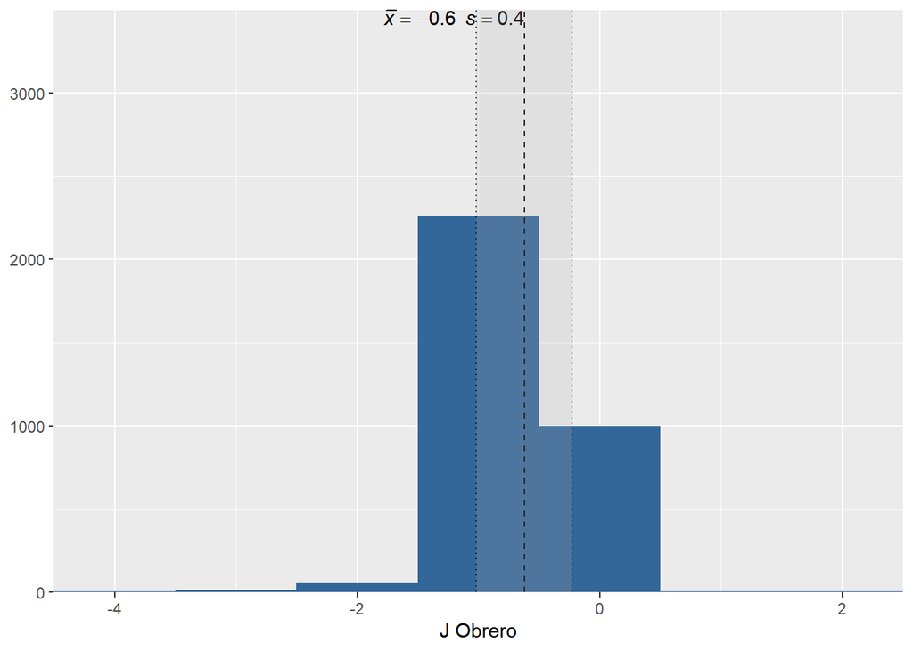

```r
## Histograms
sjPlot::plot_frq(procjv$sj_obrero, type = "histogram", show.mean = TRUE)
```

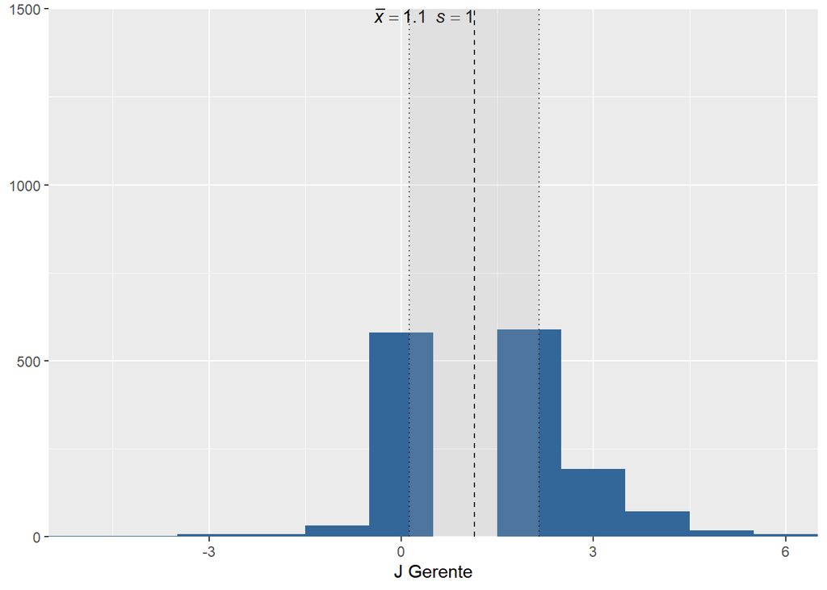

```r
sjPlot::plot_frq(procjv$sj_ceo, type = "histogram", show.mean = TRUE)
```

```r
## Creacion de sense of justicer categorico

procjv$sj_ceo_cat[procjv$sj_ceo == 0] <- 0
procjv$sj_ceo_cat[procjv$sj_ceo < 0] <- 1
procjv$sj_ceo_cat[procjv$sj_ceo > 0] <- 2

procjv$sj_obrero_cat[procjv$sj_obrero == 0] <- 0
procjv$sj_obrero_cat[procjv$sj_obrero < 0] <- 1
procjv$sj_obrero_cat[procjv$sj_obrero > 0] <- 2

procjv$sj_obrero_cat <- sjlabelled::set_label(procjv$sj_obrero_cat, label = "J Obrero")
procjv$sj_ceo_cat <- sjlabelled::set_label(procjv$sj_ceo_cat, label = "J Gerente")

procjv$sj_ceo_cat_factor <- factor(procjv$sj_ceo_cat, levels = c(0,1,2), labels = c("Justo", "Subrecompensa", "Sobrerecompensa"))
procjv$sj_obrero_cat_factor <- factor(procjv$sj_obrero_cat, levels = c(0,1,2), labels = c("Justo", "Subrecompensa", "Sobrerecompensa"))

procjv$sj_obrero_cat_factor <- sjlabelled::set_label(procjv$sj_obrero_cat_factor, label = "J Obrero")
procjv$sj_ceo_cat_factor <- sjlabelled::set_label(procjv$sj_ceo_cat_factor, label = "J Gerente")


sjmisc::frq(procjv$sj_ceo_cat_factor)
```

J Gerente (x) # total N=3417 valid N=3238 mean=2.80 sd=0.58

## 2.17 Value | N | Raw % | Valid % | Cum. %

Justo | 282 | 8.25 | 8.71 | 8.71 Subrecompensa | 73 | 2.14 | 2.25 | 10.96 Sobrerecompensa | 2883 | 84.37 | 89.04 | 100.00 | 179 | 5.24 | |

```r
sjmisc::frq(procjv$sj_obrero_cat_factor)
```

J Obrero (x) # total N=3417 valid N=3344 mean=1.98 sd=0.18

## 2.18 Value | N | Raw % | Valid % | Cum. %

Justo | 85 | 2.49 | 2.54 | 2.54 Subrecompensa | 3233 | 94.62 | 96.68 | 99.22 Sobrerecompensa | 26 | 0.76 | 0.78 | 100.00 | 73 | 2.14 | |

## 2.19 Grupos Desaventajados: Ingresos

### 2.19.1 Descriptivo

```r
sjmisc::descr(procjv$ingreso,
      show = c("label","range", "mean", "sd", "NA.prc", "n"))%>%
      kable(.,"markdown")
```

| var | label | n | NA.prc | mean | sd | range |
| --- | --- | --- | --- | --- | --- | --- |
| dd | dd | 2129 | 37.69388 | 509831.1 | 584119.7 | 15000999 (-999-1.5e+07) |

```r
table1::table1(~ingreso, data = procjv)
```

|  | Overall (N=3417) |
| --- | --- |
| ingreso |  |
| Mean (SD) | 510000 (584000) |
| Median [Min, Max] | 400000 [-999, 15000000] |
| Missing | 1288 (37.7%) |

### 2.19.2 Recodificacion

```r
# Recoficiacion NA
procjv$ingreso<- set_na(procjv$ingreso, na = c(-888,-999,0), drop.levels = TRUE, as.tag = FALSE)

# Etiquetar variable
procjv$ingreso <- sjlabelled::set_label(procjv$ingreso, label = "Ingresos")
```

### 2.19.3 Descriptivo final

```r
sjmisc::descr(procjv$ingreso,
      show = c("label","range", "mean", "sd", "NA.prc", "n"))%>%
      kable(.,"markdown")
```

| var | label | n | NA.prc | mean | sd | range |
| --- | --- | --- | --- | --- | --- | --- |
| dd | Ingresos | 2014 | 41.05941 | 538995.5 | 587310.3 | 14980000 (20000-1.5e+07) |

```r
table1::table1(~ingreso, data = procjv)
```

|  | Overall (N=3417) |
| --- | --- |
| Ingresos |  |
| Mean (SD) | 539000 (587000) |
| Median [Min, Max] | 400000 [20000, 15000000] |
| Missing | 1403 (41.1%) |

## 2.20 Grupos Desaventajados: Ingresos tramos

```r
sjmisc::frq(procjv$ingreso_tramos)
```

Ingreso mensual del entrevistado (en tramos) (2019) (x) # total N=3417 valid N=107 mean=-177.94 sd=393.01

## 2.21 Value | Label | N | Raw % | Valid % | Cum. %

-999 | No Responde (no leer) | 19 | 0.56 | 17.76 | 17.76 -888 | No Sabe (no leer) | 1 | 0.03 | 0.93 | 18.69 1 | Menos de $40.000 mensuales liquidos | 4 | 0.12 | 3.74 | 22.43 2 | De $40.001 a $85.000 mensuales liquidos | 3 | 0.09 | 2.80 | 25.23 3 | De $85.001 a $125.000 mensuales liquidos | 2 | 0.06 | 1.87 | 27.10 4 | De $125.001 a $170.000 mensuales liquidos | 6 | 0.18 | 5.61 | 32.71 5 | De $170.001 a $210.000 mensuales liquidos | 8 | 0.23 | 7.48 | 40.19 6 | De $210.001 a $230.000 mensuales liquidos | 2 | 0.06 | 1.87 | 42.06 7 | De $230.001 a $280.000 mensuales liquidos | 1 | 0.03 | 0.93 | 42.99 8 | De $280.001 a $320.000 mensuales liquidos | 5 | 0.15 | 4.67 | 47.66 9 | De $320.001 a $360.000 mensuales liquidos | 9 | 0.26 | 8.41 | 56.07 10 | De $360.001 a $400.000 mensuales liquidos | 7 | 0.20 | 6.54 | 62.62 11 | De $400.001 a $465.000 mensuales liquidos | 10 | 0.29 | 9.35 | 71.96 12 | De $465.001 a $540.000 mensuales liquidos | 4 | 0.12 | 3.74 | 75.70 13 | De $540.001 a $665.000 mensuales liquidos | 4 | 0.12 | 3.74 | 79.44 14 | De $665.001 a $850.000 mensuales liquidos | 8 | 0.23 | 7.48 | 86.92 15 | De $850.001 a $1.300.000 mensuales liquidos | 7 | 0.20 | 6.54 | 93.46 16 | Mas de $1.300.001 a mensuales liquidos | 7 | 0.20 | 6.54 | 100.00 | | 3310 | 96.87 | |

### 2.21.1 Recodificacion

```r
# Recoficiacion NA
procjv$ingreso_tramos<- set_na(procjv$ingreso_tramos, na = c(-888,-999), drop.levels = TRUE, as.tag = FALSE)

# Creacion variable factor
procjv$ingreso_tramos_factor <- factor(procjv$ingreso_tramos, levels = c(1:16), labels = c("Menos de $40.000 mensuales liquidos",
                                                                                                     "De $40.001 a $85.000 mensuales liquidos",
                                                                                                     "De $85.001 a $125.000 mensuales liquidos",
                                                                                                     "De $125.001 a $170.000 mensuales liquidos",
                                                                                                     "De $170.001 a $210.000 mensuales liquidos",
                                                                                                     "De $210.001 a $230.000 mensuales liquidos",
                                                                                                     "De $230.001 a $280.000 mensuales liquidos",
                                                                                                     "De $280.001 a $320.000 mensuales liquidos",
                                                                                                     "De $320.001 a $360.000 mensuales liquidos",
                                                                                                     "De $360.001 a $400.000 mensuales liquidos",
                                                                                                     "De $400.001 a $465.000 mensuales liquidos",
                                                                                                     "De $465.001 a $540.000 mensuales liquidos",
                                                                                                     "De $540.001 a $665.000 mensuales liquidos",
                                                                                                     "De $665.001 a $850.000 mensuales liquidos",
                                                                                                     "De $850.001 a $1.300.000 mensuales liquidos",
                                                                                                     "Mas de $1.300.001 a mensuales liquidos"))

# Etiquetado variable factor
procjv$ingreso_tramos_factor <- sjlabelled::set_label(procjv$ingreso_tramos_factor, label = "Ingreso mensual del entrevistado en tramos")

# Imputar marcas de clase de ingreso tramo a ingreso monto

# Pero antes, saquemos el promedio de la gente que tiene ingresos mayores al monto del último tramo de ingreso (1.300.001)

ingresos <- procjv$ingreso[procjv$ingreso > 1300001]
ingresos.base <- data.frame(ingresos)
ingresos.base <- na.omit(ingresos.base)
mean(ingresos.base$ingresos)
```

[1] 2221359

```r
# El promedio de las 103 personas que tienen ingresos mayores a 1.300.001 es de 2.221.359, por lo que ese será el valor a imputar

procjv$ingreso[procjv$ingreso_tramos == 1] <- 20000
procjv$ingreso[procjv$ingreso_tramos == 2] <- 62500
procjv$ingreso[procjv$ingreso_tramos == 3] <- 105000
procjv$ingreso[procjv$ingreso_tramos == 4] <- 147500
procjv$ingreso[procjv$ingreso_tramos == 5] <- 190000
procjv$ingreso[procjv$ingreso_tramos == 6] <- 220000
procjv$ingreso[procjv$ingreso_tramos == 7] <- 255000
procjv$ingreso[procjv$ingreso_tramos == 8] <- 300000
procjv$ingreso[procjv$ingreso_tramos == 9] <- 340000
procjv$ingreso[procjv$ingreso_tramos == 10] <- 380000
procjv$ingreso[procjv$ingreso_tramos == 11] <- 432500
procjv$ingreso[procjv$ingreso_tramos == 12] <- 502500
procjv$ingreso[procjv$ingreso_tramos == 13] <- 602500
procjv$ingreso[procjv$ingreso_tramos == 14] <- 757500
procjv$ingreso[procjv$ingreso_tramos == 15] <- 1075000
procjv$ingreso[procjv$ingreso_tramos == 16] <- 2221359

# Crear variable de quintiles

# Construccion ingresos per capita quintiles
procjv <- procjv %>% mutate(quintiles_ingreso = ntile(ingreso,5))

## Recuperar NA
procjv$quintiles_ingreso[is.na(procjv$quintiles_ingreso)] <- 99

# Construccion ingresos per capita quintiles factor
procjv$quintiles_ingreso_factor <- factor(procjv$quintiles_ingreso, levels = c(1,2,3,4,5,99), labels = c("Quintil 1", "Quintil 2", "Quintil 3", "Quintil 4", "Quintil 5", "No sabe/No responde"))
procjv$quintiles_ingreso_factor <- set_label(procjv$quintiles_ingreso_factor,label = "Quintiles de ingreso del entrevistado ")

# Construccion ingresos per capita quintiles factor con NS/NR al medio para correlaciones
procjv$quintiles_ingreso_factor_cor <- factor(procjv$quintiles_ingreso, levels = c(1,2,99,3,4,5), labels = c("Quintil 1", "Quintil 2", "Quintil 3", "No sabe/No responde", "Quintil 4", "Quintil 5"))
procjv$quintiles_ingreso_factor_cor <- set_label(procjv$quintiles_ingreso_factor,label = "Quintiles de de ingreso del entrevistado (NS/NR al medio) ")
```

### 2.21.2 Descriptivo final

```r
sjmisc::frq(procjv$ingreso_tramos)
```

Ingreso mensual del entrevistado (en tramos) (2019) (x) # total N=3417 valid N=87 mean=9.53 sd=4.44

## 2.22 Value | Label | N | Raw % | Valid % | Cum. %

```
1 |         Menos de $40.000 mensuales liquidos |    4 |  0.12 |    4.60 |   4.60
2 |     De $40.001 a $85.000 mensuales liquidos |    3 |  0.09 |    3.45 |   8.05
3 |    De $85.001 a $125.000 mensuales liquidos |    2 |  0.06 |    2.30 |  10.34
4 |   De $125.001 a $170.000 mensuales liquidos |    6 |  0.18 |    6.90 |  17.24
5 |   De $170.001 a $210.000 mensuales liquidos |    8 |  0.23 |    9.20 |  26.44
6 |   De $210.001 a $230.000 mensuales liquidos |    2 |  0.06 |    2.30 |  28.74
7 |   De $230.001 a $280.000 mensuales liquidos |    1 |  0.03 |    1.15 |  29.89
8 |   De $280.001 a $320.000 mensuales liquidos |    5 |  0.15 |    5.75 |  35.63
9 |   De $320.001 a $360.000 mensuales liquidos |    9 |  0.26 |   10.34 |  45.98
```

10 | De $360.001 a $400.000 mensuales liquidos | 7 | 0.20 | 8.05 | 54.02 11 | De $400.001 a $465.000 mensuales liquidos | 10 | 0.29 | 11.49 | 65.52 12 | De $465.001 a $540.000 mensuales liquidos | 4 | 0.12 | 4.60 | 70.11 13 | De $540.001 a $665.000 mensuales liquidos | 4 | 0.12 | 4.60 | 74.71 14 | De $665.001 a $850.000 mensuales liquidos | 8 | 0.23 | 9.20 | 83.91 15 | De $850.001 a $1.300.000 mensuales liquidos | 7 | 0.20 | 8.05 | 91.95 16 | Mas de $1.300.001 a mensuales liquidos | 7 | 0.20 | 8.05 | 100.00 | | 3330 | 97.45 | |

```r
sjmisc::frq(procjv$ingreso_tramos_factor)
```

Ingreso mensual del entrevistado en tramos (x) # total N=3417 valid N=87 mean=9.53 sd=4.44

## 2.23 Value | N | Raw % | Valid % | Cum. %

Menos de $40.000 mensuales liquidos | 4 | 0.12 | 4.60 | 4.60 De $40.001 a $85.000 mensuales liquidos | 3 | 0.09 | 3.45 | 8.05 De $85.001 a $125.000 mensuales liquidos | 2 | 0.06 | 2.30 | 10.34 De $125.001 a $170.000 mensuales liquidos | 6 | 0.18 | 6.90 | 17.24 De $170.001 a $210.000 mensuales liquidos | 8 | 0.23 | 9.20 | 26.44 De $210.001 a $230.000 mensuales liquidos | 2 | 0.06 | 2.30 | 28.74 De $230.001 a $280.000 mensuales liquidos | 1 | 0.03 | 1.15 | 29.89 De $280.001 a $320.000 mensuales liquidos | 5 | 0.15 | 5.75 | 35.63 De $320.001 a $360.000 mensuales liquidos | 9 | 0.26 | 10.34 | 45.98 De $360.001 a $400.000 mensuales liquidos | 7 | 0.20 | 8.05 | 54.02 De $400.001 a $465.000 mensuales liquidos | 10 | 0.29 | 11.49 | 65.52 De $465.001 a $540.000 mensuales liquidos | 4 | 0.12 | 4.60 | 70.11 De $540.001 a $665.000 mensuales liquidos | 4 | 0.12 | 4.60 | 74.71 De $665.001 a $850.000 mensuales liquidos | 8 | 0.23 | 9.20 | 83.91 De $850.001 a $1.300.000 mensuales liquidos | 7 | 0.20 | 8.05 | 91.95 Mas de $1.300.001 a mensuales liquidos | 7 | 0.20 | 8.05 | 100.00 | 3330 | 97.45 | |

## 2.24 Just Dist: Ingreso justo

**NOTA:** Esta variable se usará para construir una variable de sentido de justicia donde el *Observador* y el *Recompensado* son la misma persona.

### 2.24.1 Descriptivo

```r
sjmisc::descr(procjv$ingreso_justo,
      show = c("label","range", "mean", "sd", "NA.prc", "n"))%>%
      kable(.,"markdown")
```

| var | label | n | NA.prc | mean | sd | range |
| --- | --- | --- | --- | --- | --- | --- |
| dd | dd | 2129 | 37.69388 | 808688.6 | 745314.8 | 15000999 (-999-1.5e+07) |

```r
table1::table1(~ingreso_justo, data = procjv)
```

|  | Overall (N=3417) |
| --- | --- |
| ingreso_justo |  |
| Mean (SD) | 809000 (745000) |
| Median [Min, Max] | 600000 [-999, 15000000] |
| Missing | 1288 (37.7%) |

### 2.24.2 Recodificacion

```r
# Recoficiacion NA
procjv$ingreso_justo<- set_na(procjv$ingreso_justo, na = c(-888,-999,0), drop.levels = TRUE, as.tag = FALSE)

# Etiquetar variable
procjv$ingreso_justo <- sjlabelled::set_label(procjv$ingreso_justo, label = "Ingreso mensual justo del entrevistado")
```

### 2.24.3 Descriptivo final

```r
sjmisc::descr(procjv$ingreso_justo,
      show = c("label","range", "mean", "sd", "NA.prc", "n"))%>%
      kable(.,"markdown")
```

| var | label | n | NA.prc | mean | sd | range |
| --- | --- | --- | --- | --- | --- | --- |
| dd | Ingreso mensual justo del entrevistado | 2083 | 39.04009 | 826567 | 743617.3 | 14997000 (3000-1.5e+07) |

```r
table1::table1(~ingreso_justo, data = procjv)
```

|  | Overall (N=3417) |
| --- | --- |
| Ingreso mensual justo del entrevistado |  |
| Mean (SD) | 827000 (744000) |
| Median [Min, Max] | 600000 [3000, 15000000] |
| Missing | 1334 (39.0%) |

```r
## Descriptivos unidos

table1::table1(~ingreso + ingreso_justo, data = procjv)
```

|  | Overall (N=3417) |
| --- | --- |
| Ingresos |  |
| Mean (SD) | 540000 (586000) |
| Median [Min, Max] | 400000 [20000, 15000000] |
| Missing | 1316 (38.5%) |
| Ingreso mensual justo del entrevistado |  |
| Mean (SD) | 827000 (744000) |
| Median [Min, Max] | 600000 [3000, 15000000] |
| Missing | 1334 (39.0%) |

```r
## Creacion sense of justice

procjv$sj_entrevistado <- ln(procjv$ingreso/procjv$ingreso_justo)

procjv$sj_entrevistado_rec <- procjv$sj_entrevistado*-1

# procjv$sj_entrevistado_rec[procjv$sj_entrevistado_rec < 0] <- 0


## Etiquetado sense of justice

procjv$sj_entrevistado <- sjlabelled::set_label(procjv$sj_entrevistado, label = "J Entrevistado")
procjv$sj_entrevistado_rec <- sjlabelled::set_label(procjv$sj_entrevistado_rec, label = "J Entrevistado")

## Descriptivos sense of justice

table1::table1(~sj_obrero + sj_ceo + sj_entrevistado + sj_entrevistado_rec, data = procjv)
```

|  | Overall (N=3417) |
| --- | --- |
| J Obrero |  |
| Mean (SD) | -0.621 (0.395) |
| Median [Min, Max] | -0.539 [-4.22, 2.48] |
| Missing | 73 (2.1%) |
| J Gerente |  |
| Mean (SD) | 1.14 (1.02) |
| Median [Min, Max] | 0.916 [-5.30, 6.21] |
| Missing | 179 (5.2%) |
| J Entrevistado |  |
| Mean (SD) | -0.491 (0.406) |
| Median [Min, Max] | -0.424 [-3.40, 3.28] |
| Missing | 1349 (39.5%) |
| J Entrevistado |  |
| Mean (SD) | 0.491 (0.406) |
| Median [Min, Max] | 0.424 [-3.28, 3.40] |
| Missing | 1349 (39.5%) |

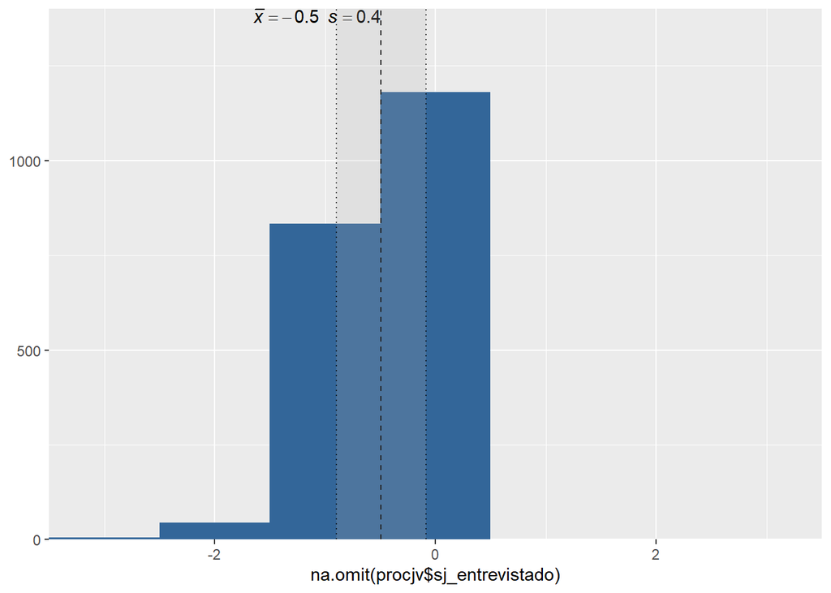

```r
## Histograms
sjPlot::plot_frq(na.omit(procjv$sj_entrevistado), type = "histogram", show.mean = TRUE)
```

```r
# Crear categorica sense of justice
procjv$sj_entrevistado_cat[procjv$sj_entrevistado == 0] <- 0
procjv$sj_entrevistado_cat[procjv$sj_entrevistado < 0] <- 1
procjv$sj_entrevistado_cat[procjv$sj_entrevistado > 0] <- 2

procjv$sj_entrevistado_cat <- sjlabelled::set_label(procjv$sj_entrevistado_cat, label = "J Entrevistado")

procjv$sj_entrevistado_cat_factor <- factor(procjv$sj_entrevistado_cat, levels = c(0,1,2), labels = c("Justo", "Subrecompensa", "Sobrerecompensa"))

procjv$sj_entrevistado_cat_factor <- sjlabelled::set_label(procjv$sj_entrevistado_cat_factor, label = "J Entrevistado")

sjmisc::frq(procjv$sj_entrevistado_cat_factor)
```

J Entrevistado (x) # total N=3417 valid N=2068 mean=1.90 sd=0.32

## 2.25 Value | N | Raw % | Valid % | Cum. %

Justo | 214 | 6.26 | 10.35 | 10.35 Subrecompensa | 1838 | 53.79 | 88.88 | 99.23 Sobrerecompensa | 16 | 0.47 | 0.77 | 100.00 | 1349 | 39.48 | |

## 2.26 Grupos desaventajados: Satisfaccion con los ingresos

### 2.26.1 Descriptivo

```r
sjmisc::frq(procjv$ingreso_satisfact)
```

Satisfaccion con ingreso (2019) (x) # total N=3417 valid N=2129 mean=0.82 sd=41.06

## 2.27 Value | Label | N | Raw % | Valid % | Cum. %

-999 | No Responde (no leer) | 2 | 0.06 | 0.09 | 0.09 -888 | No Sabe (no leer) | 2 | 0.06 | 0.09 | 0.19 1 | Totalmente insatisfecho | 212 | 6.20 | 9.96 | 10.15 2 | Insatisfecho | 1002 | 29.32 | 47.06 | 57.21 3 | Ni satisfecho ni insatisfecho | 381 | 11.15 | 17.90 | 75.11 4 | Satisfecho | 486 | 14.22 | 22.83 | 97.93 5 | Totalmente satisfecho | 44 | 1.29 | 2.07 | 100.00 | | 1288 | 37.69 | |

### 2.27.1 Recodificacion

```r
# Recoficiacion NA
procjv$ingreso_satisfact<- set_na(procjv$ingreso_satisfact, na = c(-888,-999), drop.levels = TRUE, as.tag = FALSE)

# # Aplicar inversión
# procjv$ingreso_satisfact <- car::recode(procjv$ingreso_satisfact,"
#                                               c(5) = 1;
#                                               c(4) = 2;
#                                               c(3) = 3;
#                                               c(2) = 4;
#                                               c(1) = 5")
#
# procjv$ingreso_satisfact <- sjlabelled::set_labels(procjv$ingreso_satisfact, labels = c(
#   "Totalmente insatisfecho" = 5,
#   "Insatisfecho" = 4,
#   "Ni satisfecho ni insatisfecho" = 3,
#   "Satisfecho" = 2,
#   "Totalmente satisfecho" = 1
# ))
#
#
# # Creación variable factor
# procjv$ingreso_satisfact_factor <- factor(procjv$ingreso_satisfact, levels = c(1:5), labels = c("Totalmente satisfecho", "Satisfecho", "Ni satisfecho ni insatisfecho", "Insatisfecho", "Totalmente insatisfecho"))
#

# Creacion variable factor
procjv$ingreso_satisfact_factor <- factor(procjv$ingreso_satisfact, levels = c(1,2,3,4,5), labels = c("Totalmente insatisfecho",
                                                                                                                  "Insatisfecho",
                                                                                                                  "Ni satisfecho ni insatisfecho",
                                                                                                                  "Satisfecho",
                                                                                                                  "Totalmente satisfecho"))

frq(procjv$ingreso_satisfact_factor)
```

x # total N=3417 valid N=2125 mean=2.60 sd=1.01

## 2.28 Value | N | Raw % | Valid % | Cum. %

Totalmente insatisfecho | 212 | 6.20 | 9.98 | 9.98 Insatisfecho | 1002 | 29.32 | 47.15 | 57.13 Ni satisfecho ni insatisfecho | 381 | 11.15 | 17.93 | 75.06 Satisfecho | 486 | 14.22 | 22.87 | 97.93 Totalmente satisfecho | 44 | 1.29 | 2.07 | 100.00 | 1292 | 37.81 | |

```r
procjv$ingreso_satisfact_factor <- factor(procjv$ingreso_satisfact_factor, levels = c("Totalmente satisfecho",
                                                                                         "Satisfecho",
                                                                                         "Ni satisfecho ni insatisfecho",
                                                                                         "Insatisfecho",
                                                                                         "Totalmente insatisfecho")
                                                        )

frq(procjv$ingreso_satisfact_factor)
```

x # total N=3417 valid N=2125 mean=3.40 sd=1.01

## 2.29 Value | N | Raw % | Valid % | Cum. %

Totalmente satisfecho | 44 | 1.29 | 2.07 | 2.07 Satisfecho | 486 | 14.22 | 22.87 | 24.94 Ni satisfecho ni insatisfecho | 381 | 11.15 | 17.93 | 42.87 Insatisfecho | 1002 | 29.32 | 47.15 | 90.02 Totalmente insatisfecho | 212 | 6.20 | 9.98 | 100.00 | 1292 | 37.81 | |

```r
# Etiquetado variable factor
procjv$ingreso_satisfact_factor <- sjlabelled::set_label(procjv$ingreso_satisfact_factor, label = "Satisfaccion Ingresos")
```

### 2.29.1 Descriptivo final

```r
sjmisc::frq(procjv$ingreso_satisfact)
```

Satisfaccion con ingreso (2019) (x) # total N=3417 valid N=2125 mean=2.60 sd=1.01

## 2.30 Value | Label | N | Raw % | Valid % | Cum. %

```
1 |       Totalmente insatisfecho |  212 |  6.20 |    9.98 |   9.98
2 |                  Insatisfecho | 1002 | 29.32 |   47.15 |  57.13
3 | Ni satisfecho ni insatisfecho |  381 | 11.15 |   17.93 |  75.06
4 |                    Satisfecho |  486 | 14.22 |   22.87 |  97.93
5 |         Totalmente satisfecho |   44 |  1.29 |    2.07 | 100.00
```

| | 1292 | 37.81 | |

```r
sjmisc::frq(procjv$ingreso_satisfact_factor)
```

Satisfaccion Ingresos (x) # total N=3417 valid N=2125 mean=3.40 sd=1.01

## 2.31 Value | N | Raw % | Valid % | Cum. %

Totalmente satisfecho | 44 | 1.29 | 2.07 | 2.07 Satisfecho | 486 | 14.22 | 22.87 | 24.94 Ni satisfecho ni insatisfecho | 381 | 11.15 | 17.93 | 42.87 Insatisfecho | 1002 | 29.32 | 47.15 | 90.02 Totalmente insatisfecho | 212 | 6.20 | 9.98 | 100.00 | 1292 | 37.81 | |

## 2.32 Grupos Desaventajados: Nivel educacional

### 2.32.1 Descriptivo

```r
sjmisc::frq(procjv$educ)
```

Nivel educacional (2019) (x) # total N=3417 valid N=3417 mean=4.08 sd=34.42

## 2.33 Value | Label | N | Raw % | Valid % | Cum. %

-999 | No Responde (no leer) | 4 | 0.12 | 0.12 | 0.12 -888 | No Sabe (no leer) | 0 | 0.00 | 0.00 | 0.12 1 | Sin estudios | 35 | 1.02 | 1.02 | 1.14 2 | Educacion Basica o Preparatoria incompleta | 445 | 13.02 | 13.02 | 14.16 3 | Educacion Basica o Preparatoria completa | 301 | 8.81 | 8.81 | 22.97 4 | Educacion Media o Humanidades incompleta | 453 | 13.26 | 13.26 | 36.23 5 | Educacion Media o Humanidades completa | 979 | 28.65 | 28.65 | 64.88 6 | Tecnica Superior incompleta | 138 | 4.04 | 4.04 | 68.92 7 | Tecnica Superior completa | 422 | 12.35 | 12.35 | 81.27 8 | Universitaria incompleta | 210 | 6.15 | 6.15 | 87.42 9 | Universitaria completa | 375 | 10.97 | 10.97 | 98.39 10 | Estudios de posgrado (magister o doctorado) | 55 | 1.61 | 1.61 | 100.00 | | 0 | 0.00 | |

### 2.33.1 Recodificacion

```r
# Recoficiacion NA
procjv$educ<- set_na(procjv$educ, na = c(-888,-999), drop.levels = TRUE, as.tag = FALSE)
set_na
```

```r
# Creacion variable factor
procjv$educ_factor <- factor(procjv$educ, levels = c(1:10), labels = c("Sin estudios",
                                                                                   "Educacion Basica o Preparatoria incompleta",
                                                                                   "Educacion Basica o Preparatoria completa",
                                                                                   "Educacion Media o Humanidades incompleta",
                                                                                   "Educacion Media o Humanidades completa",
                                                                                   "Tecnica Superior incompleta",
                                                                                   "Tecnica Superior completa",
                                                                                   "Universitaria incompleta",
                                                                                   "Universitaria completa",
                                                                                   "Estudios de posgrado (magister o doctorado)"))

# Etiquetado variable factor
procjv$educ_factor <- sjlabelled::set_label(procjv$educ_factor, label = "Nivel educacional del entrevistado")

# Crear variable de educacion recodificada

procjv$educ_rec <- car::recode(procjv$educ, "c(1,2)=1; c(3)=2;c(4,5)=3;c(6,7)=4;c(8,9,10)=5")

# Re etiquetar categorias

procjv$educ_rec <- set_labels(procjv$educ_rec,
            labels=c( "Primaria incompleta menos"=1,
                      "Primaria y secundaria baja"=2,
                      "Secundaria alta"=3,
                      "Terciaria ciclo corto"=4,
                      "Terciaria y Postgrado"=5))

# Etiquetado variable factor
procjv$educ_rec <- sjlabelled::set_label(procjv$educ_rec, label = "Nivel Educacional CINE 11")

# Creacion variable rec factor
procjv$educ_rec_factor <- factor(procjv$educ_rec, levels = c(1,2,3,4,5), labels = c("Primaria incompleta menos",
                                                                                                "Primaria y secundaria baja",
                                                                                                "Secundaria alta",
                                                                                                "Terciaria ciclo corto",
                                                                                                "Terciaria y Postgrado"))



# Etiquetado variable rec factor
procjv$educ_rec_factor <- sjlabelled::set_label(procjv$educ_rec_factor, label = "Nivel Educacional CINE 11")
```

### 2.33.2 Descriptivo final

```r
sjmisc::frq(procjv$educ)
```

Nivel educacional (2019) (x) # total N=3417 valid N=3413 mean=5.25 sd=2.24

## 2.34 Value | Label | N | Raw % | Valid % | Cum. %

```
1 |                                Sin estudios |  35 |  1.02 |    1.03 |   1.03
2 |  Educacion Basica o Preparatoria incompleta | 445 | 13.02 |   13.04 |  14.06
3 |    Educacion Basica o Preparatoria completa | 301 |  8.81 |    8.82 |  22.88
4 |    Educacion Media o Humanidades incompleta | 453 | 13.26 |   13.27 |  36.16
5 |      Educacion Media o Humanidades completa | 979 | 28.65 |   28.68 |  64.84
6 |                 Tecnica Superior incompleta | 138 |  4.04 |    4.04 |  68.88
7 |                   Tecnica Superior completa | 422 | 12.35 |   12.36 |  81.25
8 |                    Universitaria incompleta | 210 |  6.15 |    6.15 |  87.40
9 |                      Universitaria completa | 375 | 10.97 |   10.99 |  98.39
```

10 | Estudios de posgrado (magister o doctorado) | 55 | 1.61 | 1.61 | 100.00 | | 4 | 0.12 | |

```r
sjmisc::frq(procjv$educ_factor)
```

Nivel educacional del entrevistado (x) # total N=3417 valid N=3413 mean=5.25 sd=2.24

## 2.35 Value | N | Raw % | Valid % | Cum. %

Sin estudios | 35 | 1.02 | 1.03 | 1.03 Educacion Basica o Preparatoria incompleta | 445 | 13.02 | 13.04 | 14.06 Educacion Basica o Preparatoria completa | 301 | 8.81 | 8.82 | 22.88 Educacion Media o Humanidades incompleta | 453 | 13.26 | 13.27 | 36.16 Educacion Media o Humanidades completa | 979 | 28.65 | 28.68 | 64.84 Tecnica Superior incompleta | 138 | 4.04 | 4.04 | 68.88 Tecnica Superior completa | 422 | 12.35 | 12.36 | 81.25 Universitaria incompleta | 210 | 6.15 | 6.15 | 87.40 Universitaria completa | 375 | 10.97 | 10.99 | 98.39 Estudios de posgrado (magister o doctorado) | 55 | 1.61 | 1.61 | 100.00 | 4 | 0.12 | |

```r
sjmisc::frq(procjv$educ_rec)
```

Nivel Educacional CINE 11 (x) # total N=3417 valid N=3413 mean=3.17 sd=1.24

## 2.36 Value | Label | N | Raw % | Valid % | Cum. %

```
1 |  Primaria incompleta menos |  480 | 14.05 |   14.06 |  14.06
2 | Primaria y secundaria baja |  301 |  8.81 |    8.82 |  22.88
3 |            Secundaria alta | 1432 | 41.91 |   41.96 |  64.84
4 |      Terciaria ciclo corto |  560 | 16.39 |   16.41 |  81.25
5 |      Terciaria y Postgrado |  640 | 18.73 |   18.75 | 100.00
```

| | 4 | 0.12 | |

```r
sjmisc::frq(procjv$educ_rec_factor)
```

Nivel Educacional CINE 11 (x) # total N=3417 valid N=3413 mean=3.17 sd=1.24

## 2.37 Value | N | Raw % | Valid % | Cum. %

Primaria incompleta menos | 480 | 14.05 | 14.06 | 14.06 Primaria y secundaria baja | 301 | 8.81 | 8.82 | 22.88 Secundaria alta | 1432 | 41.91 | 41.96 | 64.84 Terciaria ciclo corto | 560 | 16.39 | 16.41 | 81.25 Terciaria y Postgrado | 640 | 18.73 | 18.75 | 100.00 | 4 | 0.12 | |

## 2.38 Grupos Desaventajados: Sexo

### 2.38.1 Descriptivo

```r
sjmisc::frq(procjv$sexo)
```

Sexo del entrevistado (2019) (x) # total N=3417 valid N=3417 mean=1.62 sd=0.48

## 2.39 Value | Label | N | Raw % | Valid % | Cum. %

```
1 | Hombre | 1282 | 37.52 |   37.52 |  37.52
2 |  Mujer | 2135 | 62.48 |   62.48 | 100.00
```

| | 0 | 0.00 | |

### 2.39.1 Recodificacion

```r
# Recoficiacion NA
procjv$sexo<- set_na(procjv$sexo, na = c(-888,-999), drop.levels = TRUE, as.tag = FALSE)

# Creacion variable factor
procjv$sexo_factor <- factor(procjv$sexo, levels = c(1,2), labels = c("Hombre", "Mujer"))

# Etiquetado variable factor
procjv$sexo_factor <- sjlabelled::set_label(procjv$sexo_factor, label = "Sexo")
```

### 2.39.2 Desriptivo final

```r
sjmisc::frq(procjv$sexo)
```

Sexo del entrevistado (2019) (x) # total N=3417 valid N=3417 mean=1.62 sd=0.48

## 2.40 Value | Label | N | Raw % | Valid % | Cum. %

```
1 | Hombre | 1282 | 37.52 |   37.52 |  37.52
2 |  Mujer | 2135 | 62.48 |   62.48 | 100.00
```

| | 0 | 0.00 | |

```r
sjmisc::frq(procjv$sexo_factor)
```

Sexo (x) # total N=3417 valid N=3417 mean=1.62 sd=0.48

## 2.41 Value | N | Raw % | Valid % | Cum. %

Hombre | 1282 | 37.52 | 37.52 | 37.52 Mujer | 2135 | 62.48 | 62.48 | 100.00 | 0 | 0.00 | |

## 2.42 Grupos Desaventajados: Pertenencia a Pueblos indigenas

### 2.42.1 Descriptivo

```r
sjmisc::frq(procjv$indigena)
```

Pertenencia a pueblo indigena (2019) (x) # total N=3417 valid N=3417 mean=-1.44 sd=98.19

## 2.43 Value | Label | N | Raw % | Valid % | Cum. %

-999 | No Responde (no leer) | 9 | 0.26 | 0.26 | 0.26 -888 | No Sabe (no leer) | 30 | 0.88 | 0.88 | 1.14 1 | Mapuche | 304 | 8.90 | 8.90 | 10.04 2 | Aimara | 17 | 0.50 | 0.50 | 10.54 3 | Rapa Nui | 1 | 0.03 | 0.03 | 10.56 4 | Likan Antai | 0 | 0.00 | 0.00 | 10.56 5 | Quechua | 6 | 0.18 | 0.18 | 10.74 6 | Colla | 11 | 0.32 | 0.32 | 11.06 7 | Diaguita | 39 | 1.14 | 1.14 | 12.20 8 | Kawesqar | 0 | 0.00 | 0.00 | 12.20 9 | Yagan o Yamana | 2 | 0.06 | 0.06 | 12.26 10 | Ninguno | 2990 | 87.50 | 87.50 | 99.77 11 | Otro | 8 | 0.23 | 0.23 | 100.00 | | 0 | 0.00 | |

### 2.43.1 Recodificacion

```r
# Recoficiacion NA
procjv$indigena <- set_na(procjv$indigena, na = c(-888,-999), drop.levels = TRUE, as.tag = FALSE)

# Crear variable de pertenencia a grupos indigenas recodificada

procjv$indigena_rec <- car::recode(procjv$indigena, "c(10)=1;
                                   c(2,3,4,5,6,7,8,9,11)=2;
                                   c(1)=3")

procjv$indigena_rec <- sjlabelled::set_label(procjv$indigena_rec, label = "Pertenencia a Pueblo Indigena")

# Creacion variable factor
procjv$indigena_rec_factor <- factor(procjv$indigena_rec, levels = c(1,2,3), labels = c("Ninguno", "Otro pueblo", "Mapuche"))

# Etiquetado variable factor
procjv$indigena_rec_factor <- sjlabelled::set_label(procjv$indigena_rec_factor, label = "Pertenencia a Pueblo Indigena")
```

### 2.43.2 Desriptivo final

```r
sjmisc::frq(procjv$indigena)
```

Pertenencia a pueblo indigena (2019) (x) # total N=3417 valid N=3378 mean=9.09 sd=2.65

## 2.44 Value | Label | N | Raw % | Valid % | Cum. %

```
1 |        Mapuche |  304 |  8.90 |    9.00 |   9.00
2 |         Aimara |   17 |  0.50 |    0.50 |   9.50
3 |       Rapa Nui |    1 |  0.03 |    0.03 |   9.53
4 |    Likan Antai |    0 |  0.00 |    0.00 |   9.53
5 |        Quechua |    6 |  0.18 |    0.18 |   9.71
6 |          Colla |   11 |  0.32 |    0.33 |  10.04
7 |       Diaguita |   39 |  1.14 |    1.15 |  11.19
8 |       Kawesqar |    0 |  0.00 |    0.00 |  11.19
9 | Yagan o Yamana |    2 |  0.06 |    0.06 |  11.25
```

10 | Ninguno | 2990 | 87.50 | 88.51 | 99.76 11 | Otro | 8 | 0.23 | 0.24 | 100.00 | | 39 | 1.14 | |

```r
sjmisc::frq(procjv$indigena_rec_factor)
```

Pertenencia a Pueblo Indigena (x) # total N=3417 valid N=3378 mean=1.20 sd=0.59

## 2.45 Value | N | Raw % | Valid % | Cum. %

Ninguno | 2990 | 87.50 | 88.51 | 88.51 Otro pueblo | 84 | 2.46 | 2.49 | 91.00 Mapuche | 304 | 8.90 | 9.00 | 100.00 | 39 | 1.14 | |

## 2.46 Ideología: Sociedad Ideal (SDO)

### 2.46.1 Descriptivo

```r
sjmisc::frq(procjv$sdo_soc_ideal)
```

Grado de acuerdo: Sociedad grupos superiores e inferiores (2019) (x) # total N=3417 valid N=3417 mean=-7.64 sd=95.33

## 2.47 Value | Label | N | Raw % | Valid % | Cum. %

-999 | No Responde (no leer) | 6 | 0.18 | 0.18 | 0.18 -888 | No Sabe (no leer) | 32 | 0.94 | 0.94 | 1.11 1 | Totalmente en desacuerdo | 535 | 15.66 | 15.66 | 16.77 2 | En desacuerdo | 1515 | 44.34 | 44.34 | 61.11 3 | Ni de acuerdo ni en desacuerdo | 649 | 18.99 | 18.99 | 80.10 4 | De acuerdo | 599 | 17.53 | 17.53 | 97.63 5 | Totalmente de acuerdo | 81 | 2.37 | 2.37 | 100.00 | | 0 | 0.00 | |

### 2.47.1 Recodificacion

```r
# Recoficiacion NA
procjv$sdo_soc_ideal <- set_na(procjv$sdo_soc_ideal, na = c(-888,-999), drop.levels = TRUE, as.tag = FALSE)

# Creacion variable factor
procjv$sdo_soc_ideal_factor <- factor(procjv$sdo_soc_ideal, levels = c(1:5), labels = c("Totalmente en desacuerdo", "En desacuerdo", "Ni de acuerdo ni en desacuerdo", "De acuerdo", "Totalmente de acuerdo"))

# Etiquetado variable factor
procjv$sdo_soc_ideal_factor <- sjlabelled::set_label(procjv$sdo_soc_ideal_factor, label = "SDO: Sociedad ideal requiere grupos superiores e inferiores")
```

### 2.47.2 Descriptivo final

```r
sjmisc::frq(procjv$sdo_soc_ideal)
```

Grado de acuerdo: Sociedad grupos superiores e inferiores (2019) (x) # total N=3417 valid N=3379 mean=2.46 sd=1.03

## 2.48 Value | Label | N | Raw % | Valid % | Cum. %

```
1 |       Totalmente en desacuerdo |  535 | 15.66 |   15.83 |  15.83
2 |                  En desacuerdo | 1515 | 44.34 |   44.84 |  60.67
3 | Ni de acuerdo ni en desacuerdo |  649 | 18.99 |   19.21 |  79.88
4 |                     De acuerdo |  599 | 17.53 |   17.73 |  97.60
5 |          Totalmente de acuerdo |   81 |  2.37 |    2.40 | 100.00
```

| | 38 | 1.11 | |

```r
sjmisc::frq(procjv$sdo_soc_ideal_factor)
```

SDO: Sociedad ideal requiere grupos superiores e inferiores (x) # total N=3417 valid N=3379 mean=2.46 sd=1.03

## 2.49 Value | N | Raw % | Valid % | Cum. %

Totalmente en desacuerdo | 535 | 15.66 | 15.83 | 15.83 En desacuerdo | 1515 | 44.34 | 44.84 | 60.67 Ni de acuerdo ni en desacuerdo | 649 | 18.99 | 19.21 | 79.88 De acuerdo | 599 | 17.53 | 17.73 | 97.60 Totalmente de acuerdo | 81 | 2.37 | 2.40 | 100.00 | 38 | 1.11 | |

## 2.50 Ideología: Grupos Inferiores (SDO)

### 2.50.1 Descriptivo

```r
sjmisc::frq(procjv$sdo_grupos_inferiores)
```

Grado de acuerdo: Hay grupos de personas inferiores (2019) (x) # total N=3417 valid N=3417 mean=-5.85 sd=88.26

## 2.51 Value | Label | N | Raw % | Valid % | Cum. %

-999 | No Responde (no leer) | 7 | 0.20 | 0.20 | 0.20 -888 | No Sabe (no leer) | 25 | 0.73 | 0.73 | 0.94 1 | Totalmente en desacuerdo | 491 | 14.37 | 14.37 | 15.31 2 | En desacuerdo | 1253 | 36.67 | 36.67 | 51.98 3 | Ni de acuerdo ni en desacuerdo | 472 | 13.81 | 13.81 | 65.79 4 | De acuerdo | 1058 | 30.96 | 30.96 | 96.75 5 | Totalmente de acuerdo | 111 | 3.25 | 3.25 | 100.00 | | 0 | 0.00 | |

### 2.51.1 Recodificacion

```r
# Recoficiacion NA
procjv$sdo_grupos_inferiores <- set_na(procjv$sdo_grupos_inferiores, na = c(-888,-999), drop.levels = TRUE, as.tag = FALSE)

# Creacion variable factor
procjv$sdo_grupos_inferiores_factor <- factor(procjv$sdo_grupos_inferiores, levels = c(1:5), labels = c("Totalmente en desacuerdo", "En desacuerdo", "Ni de acuerdo ni en desacuerdo", "De acuerdo", "Totalmente de acuerdo"))

# Etiquetado variable factor
procjv$sdo_grupos_inferiores_factor <- sjlabelled::set_label(procjv$sdo_grupos_inferiores_factor, label = "SDO: Grupos son inferiores que otros")
```

### 2.51.2 Descriptivo final

```r
sjmisc::frq(procjv$sdo_grupos_inferiores)
```

Grado de acuerdo: Hay grupos de personas inferiores (2019) (x) # total N=3417 valid N=3385 mean=2.72 sd=1.15

## 2.52 Value | Label | N | Raw % | Valid % | Cum. %

```
1 |       Totalmente en desacuerdo |  491 | 14.37 |   14.51 |  14.51
2 |                  En desacuerdo | 1253 | 36.67 |   37.02 |  51.52
3 | Ni de acuerdo ni en desacuerdo |  472 | 13.81 |   13.94 |  65.47
4 |                     De acuerdo | 1058 | 30.96 |   31.26 |  96.72
5 |          Totalmente de acuerdo |  111 |  3.25 |    3.28 | 100.00
```

| | 32 | 0.94 | |

```r
sjmisc::frq(procjv$sdo_grupos_inferiores_factor)
```

SDO: Grupos son inferiores que otros (x) # total N=3417 valid N=3385 mean=2.72 sd=1.15

## 2.53 Value | N | Raw % | Valid % | Cum. %

Totalmente en desacuerdo | 491 | 14.37 | 14.51 | 14.51 En desacuerdo | 1253 | 36.67 | 37.02 | 51.52 Ni de acuerdo ni en desacuerdo | 472 | 13.81 | 13.94 | 65.47 De acuerdo | 1058 | 30.96 | 31.26 | 96.72 Totalmente de acuerdo | 111 | 3.25 | 3.28 | 100.00 | 32 | 0.94 | |

## 2.54 Ideología: Oportunidades Iguales (SDO)

### 2.54.1 Descriptivo

```r
sjmisc::frq(procjv$sdo_oportunidades_iguales)
```

Grado de acuerdo: Dar a todos las mismas oportunidades (2019) (x) # total N=3417 valid N=3417 mean=0.96 sd=55.63

## 2.55 Value | Label | N | Raw % | Valid % | Cum. %

-999 | No Responde (no leer) | 5 | 0.15 | 0.15 | 0.15 -888 | No Sabe (no leer) | 7 | 0.20 | 0.20 | 0.35 1 | Totalmente en desacuerdo | 16 | 0.47 | 0.47 | 0.82 2 | En desacuerdo | 75 | 2.19 | 2.19 | 3.01 3 | Ni de acuerdo ni en desacuerdo | 108 | 3.16 | 3.16 | 6.18 4 | De acuerdo | 2034 | 59.53 | 59.53 | 65.70 5 | Totalmente de acuerdo | 1172 | 34.30 | 34.30 | 100.00 | | 0 | 0.00 | |

### 2.55.1 Recodificacion

```r
# Recoficiacion NA
procjv$sdo_oportunidades_iguales <- set_na(procjv$sdo_oportunidades_iguales, na = c(-888,-999), drop.levels = TRUE, as.tag = FALSE)

# Aplicar inversión
procjv$sdo_oportunidades_iguales <- car::recode(procjv$sdo_oportunidades_iguales,"
                                              c(5) = 1;
                                              c(4) = 2;
                                              c(3) = 3;
                                              c(2) = 4;
                                              c(1) = 5")

procjv$sdo_oportunidades_iguales <- sjlabelled::set_labels(procjv$sdo_oportunidades_iguales, labels = c(
  "Totalmente en desacuerdo" = 5,
  "En desacuerdo" = 4,
  "Ni de acuerdo ni en desacuerdo" = 3,
  "De acuerdo" = 2,
  "Totalmente de acuerdo" = 1
))

procjv$sdo_oportunidades_iguales <- sjlabelled::set_label(procjv$sdo_oportunidades_iguales, label = "SDO: Misma oportunidad entre grupos (inversion aplicada)")

# Creación variable factor
procjv$sdo_oportunidades_iguales_factor <- factor(procjv$sdo_oportunidades_iguales, levels = c(1:5), labels = c("Totalmente de acuerdo", "De acuerdo", "Ni de acuerdo ni en desacuerdo", "En desacuerdo", "Totalmente en desacuerdo"))

# Etiquetado variable factor
procjv$sdo_oportunidades_iguales_factor <- sjlabelled::set_label(procjv$sdo_oportunidades_iguales_factor, label = "SDO: Misma oportunidad entre grupos (inversion aplicada)")
```

### 2.55.2 Descriptivo final

```r
sjmisc::frq(procjv$sdo_oportunidades_iguales)
```

SDO: Misma oportunidad entre grupos (inversion aplicada) (x) # total N=3417 valid N=3405 mean=1.75 sd=0.66

## 2.56 Value | Label | N | Raw % | Valid % | Cum. %

```
1 |          Totalmente de acuerdo | 1172 | 34.30 |   34.42 |  34.42
2 |                     De acuerdo | 2034 | 59.53 |   59.74 |  94.16
3 | Ni de acuerdo ni en desacuerdo |  108 |  3.16 |    3.17 |  97.33
4 |                  En desacuerdo |   75 |  2.19 |    2.20 |  99.53
5 |       Totalmente en desacuerdo |   16 |  0.47 |    0.47 | 100.00
```

| | 12 | 0.35 | |

```r
sjmisc::frq(procjv$sdo_oportunidades_iguales_factor)
```

SDO: Misma oportunidad entre grupos (inversion aplicada) (x) # total N=3417 valid N=3405 mean=1.75 sd=0.66

## 2.57 Value | N | Raw % | Valid % | Cum. %

Totalmente de acuerdo | 1172 | 34.30 | 34.42 | 34.42 De acuerdo | 2034 | 59.53 | 59.74 | 94.16 Ni de acuerdo ni en desacuerdo | 108 | 3.16 | 3.17 | 97.33 En desacuerdo | 75 | 2.19 | 2.20 | 99.53 Totalmente en desacuerdo | 16 | 0.47 | 0.47 | 100.00 | 12 | 0.35 | |

## 2.58 Ideología: Condiciones iguales (SDO)

### 2.58.1 Descriptivo

```r
sjmisc::frq(procjv$sdo_condiciones_iguales)
```

Grado de acuerdo: Igualar condiciones diferentes grupos (2019) (x) # total N=3417 valid N=3417 mean=0.43 sd=59.64

## 2.59 Value | Label | N | Raw % | Valid % | Cum. %

-999 | No Responde (no leer) | 5 | 0.15 | 0.15 | 0.15 -888 | No Sabe (no leer) | 9 | 0.26 | 0.26 | 0.41 1 | Totalmente en desacuerdo | 8 | 0.23 | 0.23 | 0.64 2 | En desacuerdo | 63 | 1.84 | 1.84 | 2.49 3 | Ni de acuerdo ni en desacuerdo | 131 | 3.83 | 3.83 | 6.32 4 | De acuerdo | 2065 | 60.43 | 60.43 | 66.75 5 | Totalmente de acuerdo | 1136 | 33.25 | 33.25 | 100.00 | | 0 | 0.00 | |

### 2.59.1 Recodificacion

```r
# Recoficiacion NA
procjv$sdo_condiciones_iguales <- set_na(procjv$sdo_condiciones_iguales, na = c(-888,-999), drop.levels = TRUE, as.tag = FALSE)

# Aplicar inversión
procjv$sdo_condiciones_iguales <- car::recode(procjv$sdo_condiciones_iguales,"
                                              c(5) = 1;
                                              c(4) = 2;
                                              c(3) = 3;
                                              c(2) = 4;
                                              c(1) = 5")

procjv$sdo_condiciones_iguales <- sjlabelled::set_labels(procjv$sdo_condiciones_iguales, labels = c(
  "Totalmente en desacuerdo" = 5,
  "En desacuerdo" = 4,
  "Ni de acuerdo ni en desacuerdo" = 3,
  "De acuerdo" = 2,
  "Totalmente de acuerdo" = 1
))

procjv$sdo_condiciones_iguales <- sjlabelled::set_label(procjv$sdo_condiciones_iguales, label = "SDO: Condiciones iguales entre grupos (inversion aplicada)")

# Creación variable factor
procjv$sdo_condiciones_iguales_factor <- factor(procjv$sdo_condiciones_iguales, levels = c(1:5), labels = c("Totalmente de acuerdo", "De acuerdo", "Ni de acuerdo ni en desacuerdo", "En desacuerdo", "Totalmente en desacuerdo"))

# Etiquetado variable factor
procjv$sdo_condiciones_iguales_factor <- sjlabelled::set_label(procjv$sdo_condiciones_iguales_factor, label = "SDO: Condiciones iguales entre grupos (inversion aplicada)")
```

### 2.59.2 Descriptivo final

```r
sjmisc::frq(procjv$sdo_condiciones_iguales)
```

SDO: Condiciones iguales entre grupos (inversion aplicada) (x) # total N=3417 valid N=3403 mean=1.75 sd=0.64

## 2.60 Value | Label | N | Raw % | Valid % | Cum. %

```
1 |          Totalmente de acuerdo | 1136 | 33.25 |   33.38 |  33.38
2 |                     De acuerdo | 2065 | 60.43 |   60.68 |  94.06
3 | Ni de acuerdo ni en desacuerdo |  131 |  3.83 |    3.85 |  97.91
4 |                  En desacuerdo |   63 |  1.84 |    1.85 |  99.76
5 |       Totalmente en desacuerdo |    8 |  0.23 |    0.24 | 100.00
```

| | 14 | 0.41 | |

```r
sjmisc::frq(procjv$sdo_condiciones_iguales_factor)
```

SDO: Condiciones iguales entre grupos (inversion aplicada) (x) # total N=3417 valid N=3403 mean=1.75 sd=0.64

## 2.61 Value | N | Raw % | Valid % | Cum. %

Totalmente de acuerdo | 1136 | 33.25 | 33.38 | 33.38 De acuerdo | 2065 | 60.43 | 60.68 | 94.06 Ni de acuerdo ni en desacuerdo | 131 | 3.83 | 3.85 | 97.91 En desacuerdo | 63 | 1.84 | 1.85 | 99.76 Totalmente en desacuerdo | 8 | 0.23 | 0.24 | 100.00 | 14 | 0.41 | |

### 2.61.1 Otros ajustes

```r
# Crear indices para ideología

# SDO

procjv <- procjv %>% rowwise() %>% mutate(sdo_indice = sum(sdo_soc_ideal, sdo_grupos_inferiores, sdo_oportunidades_iguales, sdo_condiciones_iguales, na.rm = T)/4) # Promedias indicadores

frq(procjv$sdo_indice)
```

x # total N=3417 valid N=3417 mean=2.15 sd=0.61

## 2.62 Value | N | Raw % | Valid % | Cum. %

0.00 | 5 | 0.15 | 0.15 | 0.15 0.25 | 1 | 0.03 | 0.03 | 0.18 0.50 | 5 | 0.15 | 0.15 | 0.32 0.75 | 4 | 0.12 | 0.12 | 0.44 1.00 | 247 | 7.23 | 7.23 | 7.67 1.25 | 138 | 4.04 | 4.04 | 11.71 1.50 | 285 | 8.34 | 8.34 | 20.05 1.75 | 266 | 7.78 | 7.78 | 27.83 2.00 | 767 | 22.45 | 22.45 | 50.28 2.25 | 344 | 10.07 | 10.07 | 60.35 2.50 | 624 | 18.26 | 18.26 | 78.61 2.75 | 278 | 8.14 | 8.14 | 86.74 3.00 | 348 | 10.18 | 10.18 | 96.93 3.25 | 60 | 1.76 | 1.76 | 98.68 3.50 | 29 | 0.85 | 0.85 | 99.53 3.75 | 13 | 0.38 | 0.38 | 99.91 4.00 | 3 | 0.09 | 0.09 | 100.00 | 0 | 0.00 | |

```r
procjv$sdo_indice <- (procjv$sdo_indice-min(procjv$sdo_indice))/(max(procjv$sdo_indice)-min(procjv$sdo_indice)) # Estandarizar

procjv$sdo_indice <- sjlabelled::set_label(procjv$sdo_indice, label = "SDO Indice") # Etiquetar

# Frecuencias variables nuevas

frq(procjv$sdo_indice)
```

SDO Indice (x) # total N=3417 valid N=3417 mean=0.54 sd=0.15

## 2.63 Value | N | Raw % | Valid % | Cum. %

0.00 | 5 | 0.15 | 0.15 | 0.15 0.06 | 1 | 0.03 | 0.03 | 0.18 0.12 | 5 | 0.15 | 0.15 | 0.32 0.19 | 4 | 0.12 | 0.12 | 0.44 0.25 | 247 | 7.23 | 7.23 | 7.67 0.31 | 138 | 4.04 | 4.04 | 11.71 0.38 | 285 | 8.34 | 8.34 | 20.05 0.44 | 266 | 7.78 | 7.78 | 27.83 0.50 | 767 | 22.45 | 22.45 | 50.28 0.56 | 344 | 10.07 | 10.07 | 60.35 0.62 | 624 | 18.26 | 18.26 | 78.61 0.69 | 278 | 8.14 | 8.14 | 86.74 0.75 | 348 | 10.18 | 10.18 | 96.93 0.81 | 60 | 1.76 | 1.76 | 98.68 0.88 | 29 | 0.85 | 0.85 | 99.53 0.94 | 13 | 0.38 | 0.38 | 99.91 1.00 | 3 | 0.09 | 0.09 | 100.00 | 0 | 0.00 | |

## 2.64 Ideología: Gobierno firme (RWA)

### 2.64.1 Descriptivo

```r
sjmisc::frq(procjv$rwa_gobierno_firme)
```

Grado de acuerdo: Necesitamos un gobierno firme (2019) (x) # total N=3417 valid N=3417 mean=-4.42 sd=83.34

## 2.65 Value | Label | N | Raw % | Valid % | Cum. %

-999 | No Responde (no leer) | 8 | 0.23 | 0.23 | 0.23 -888 | No Sabe (no leer) | 20 | 0.59 | 0.59 | 0.82 1 | Totalmente en desacuerdo | 390 | 11.41 | 11.41 | 12.23 2 | En desacuerdo | 843 | 24.67 | 24.67 | 36.90 3 | Ni de acuerdo ni en desacuerdo | 473 | 13.84 | 13.84 | 50.75 4 | De acuerdo | 1254 | 36.70 | 36.70 | 87.45 5 | Totalmente de acuerdo | 429 | 12.55 | 12.55 | 100.00 | | 0 | 0.00 | |

### 2.65.1 Recodificacion

```r
# Recoficiacion NA
procjv$rwa_gobierno_firme <- set_na(procjv$rwa_gobierno_firme, na = c(-888,-999), drop.levels = TRUE, as.tag = FALSE)

# Creacion variable factor
procjv$rwa_gobierno_firme_factor <- factor(procjv$rwa_gobierno_firme, levels = c(1:5), labels = c("Totalmente en desacuerdo", "En desacuerdo", "Ni de acuerdo ni en desacuerdo", "De acuerdo", "Totalmente de acuerdo"))

# Etiquetado variable factor
procjv$rwa_gobierno_firme_factor <- sjlabelled::set_label(procjv$rwa_gobierno_firme_factor, label = "RWA: Se necesita gobierno firme")
```

### 2.65.2 Descriptivo final

```r
sjmisc::frq(procjv$rwa_gobierno_firme)
```

Grado de acuerdo: Necesitamos un gobierno firme (2019) (x) # total N=3417 valid N=3389 mean=3.14 sd=1.25

## 2.66 Value | Label | N | Raw % | Valid % | Cum. %

```
1 |       Totalmente en desacuerdo |  390 | 11.41 |   11.51 |  11.51
2 |                  En desacuerdo |  843 | 24.67 |   24.87 |  36.38
3 | Ni de acuerdo ni en desacuerdo |  473 | 13.84 |   13.96 |  50.34
4 |                     De acuerdo | 1254 | 36.70 |   37.00 |  87.34
5 |          Totalmente de acuerdo |  429 | 12.55 |   12.66 | 100.00
```

| | 28 | 0.82 | |

```r
sjmisc::frq(procjv$rwa_gobierno_firme_factor)
```

RWA: Se necesita gobierno firme (x) # total N=3417 valid N=3389 mean=3.14 sd=1.25

## 2.67 Value | N | Raw % | Valid % | Cum. %

Totalmente en desacuerdo | 390 | 11.41 | 11.51 | 11.51 En desacuerdo | 843 | 24.67 | 24.87 | 36.38 Ni de acuerdo ni en desacuerdo | 473 | 13.84 | 13.96 | 50.34 De acuerdo | 1254 | 36.70 | 37.00 | 87.34 Totalmente de acuerdo | 429 | 12.55 | 12.66 | 100.00 | 28 | 0.82 | |

## 2.68 Ideología: Mandatario fuerte (RWA)

### 2.68.1 Descriptivo

```r
sjmisc::frq(procjv$rwa_mandatario_fuerte)
```

Grado de acuerdo: Pais necesita un mandatario fuerte (2019) (x) # total N=3417 valid N=3417 mean=-7.62 sd=101.38

## 2.69 Value | Label | N | Raw % | Valid % | Cum. %

-999 | No Responde (no leer) | 14 | 0.41 | 0.41 | 0.41 -888 | No Sabe (no leer) | 27 | 0.79 | 0.79 | 1.20 1 | Totalmente en desacuerdo | 227 | 6.64 | 6.64 | 7.84 2 | En desacuerdo | 513 | 15.01 | 15.01 | 22.86 3 | Ni de acuerdo ni en desacuerdo | 448 | 13.11 | 13.11 | 35.97 4 | De acuerdo | 1619 | 47.38 | 47.38 | 83.35 5 | Totalmente de acuerdo | 569 | 16.65 | 16.65 | 100.00 | | 0 | 0.00 | |

### 2.69.1 Recodificacion

```r
# Recoficiacion NA
procjv$rwa_mandatario_fuerte <- set_na(procjv$rwa_mandatario_fuerte, na = c(-888,-999), drop.levels = TRUE, as.tag = FALSE)

# Creacion variable factor
procjv$rwa_mandatario_fuerte_factor <- factor(procjv$rwa_mandatario_fuerte, levels = c(1:5), labels = c("Totalmente en desacuerdo", "En desacuerdo", "Ni de acuerdo ni en desacuerdo", "De acuerdo", "Totalmente de acuerdo"))

# Etiquetado variable factor
procjv$rwa_mandatario_fuerte_factor <- sjlabelled::set_label(procjv$rwa_mandatario_fuerte_factor, label = "RWA: Mandatario determinado para guiarnos")
```

### 2.69.2 Descriptivo final

```r
sjmisc::frq(procjv$rwa_mandatario_fuerte)
```

Grado de acuerdo: Pais necesita un mandatario fuerte (2019) (x) # total N=3417 valid N=3376 mean=3.53 sd=1.14

## 2.70 Value | Label | N | Raw % | Valid % | Cum. %

```
1 |       Totalmente en desacuerdo |  227 |  6.64 |    6.72 |   6.72
2 |                  En desacuerdo |  513 | 15.01 |   15.20 |  21.92
3 | Ni de acuerdo ni en desacuerdo |  448 | 13.11 |   13.27 |  35.19
4 |                     De acuerdo | 1619 | 47.38 |   47.96 |  83.15
5 |          Totalmente de acuerdo |  569 | 16.65 |   16.85 | 100.00
```

| | 41 | 1.20 | |

```r
sjmisc::frq(procjv$rwa_mandatario_fuerte_factor)
```

RWA: Mandatario determinado para guiarnos (x) # total N=3417 valid N=3376 mean=3.53 sd=1.14

## 2.71 Value | N | Raw % | Valid % | Cum. %

Totalmente en desacuerdo | 227 | 6.64 | 6.72 | 6.72 En desacuerdo | 513 | 15.01 | 15.20 | 21.92 Ni de acuerdo ni en desacuerdo | 448 | 13.11 | 13.27 | 35.19 De acuerdo | 1619 | 47.38 | 47.96 | 83.15 Totalmente de acuerdo | 569 | 16.65 | 16.85 | 100.00 | 41 | 1.20 | |

## 2.72 Ideología: Valores niños (RWA)

### 2.72.1 Descriptivo

```r
sjmisc::frq(procjv$rwa_valores_ninos)
```

Grado de acuerdo: Obediencia y respeto para los ninnios (2019) (x) # total N=3417 valid N=3417 mean=-0.99 sd=64.78

## 2.73 Value | Label | N | Raw % | Valid % | Cum. %

-999 | No Responde (no leer) | 8 | 0.23 | 0.23 | 0.23 -888 | No Sabe (no leer) | 8 | 0.23 | 0.23 | 0.47 1 | Totalmente en desacuerdo | 209 | 6.12 | 6.12 | 6.58 2 | En desacuerdo | 644 | 18.85 | 18.85 | 25.43 3 | Ni de acuerdo ni en desacuerdo | 484 | 14.16 | 14.16 | 39.60 4 | De acuerdo | 1567 | 45.86 | 45.86 | 85.46 5 | Totalmente de acuerdo | 497 | 14.54 | 14.54 | 100.00 | | 0 | 0.00 | |

### 2.73.1 Recodificacion

```r
# Recoficiacion NA
procjv$rwa_valores_ninos <- set_na(procjv$rwa_valores_ninos, na = c(-888,-999), drop.levels = TRUE, as.tag = FALSE)

# Creacion variable factor
procjv$rwa_valores_ninos_factor <- factor(procjv$rwa_valores_ninos, levels = c(1:5), labels = c("Totalmente en desacuerdo", "En desacuerdo", "Ni de acuerdo ni en desacuerdo", "De acuerdo", "Totalmente de acuerdo"))

# Etiquetado variable factor
procjv$rwa_valores_ninos_factor <- sjlabelled::set_label(procjv$rwa_valores_ninos_factor, label = "RWA: Valores importantes que niños deberían aprender")
```

### 2.73.2 Descriptivo final

```r
sjmisc::frq(procjv$rwa_valores_ninos)
```

Grado de acuerdo: Obediencia y respeto para los ninnios (2019) (x) # total N=3417 valid N=3401 mean=3.44 sd=1.13

## 2.74 Value | Label | N | Raw % | Valid % | Cum. %

```
1 |       Totalmente en desacuerdo |  209 |  6.12 |    6.15 |   6.15
2 |                  En desacuerdo |  644 | 18.85 |   18.94 |  25.08
3 | Ni de acuerdo ni en desacuerdo |  484 | 14.16 |   14.23 |  39.31
4 |                     De acuerdo | 1567 | 45.86 |   46.07 |  85.39
5 |          Totalmente de acuerdo |  497 | 14.54 |   14.61 | 100.00
```

| | 16 | 0.47 | |

```r
sjmisc::frq(procjv$rwa_valores_ninos_factor)
```

RWA: Valores importantes que niños deberían aprender (x) # total N=3417 valid N=3401 mean=3.44 sd=1.13

## 2.75 Value | N | Raw % | Valid % | Cum. %

Totalmente en desacuerdo | 209 | 6.12 | 6.15 | 6.15 En desacuerdo | 644 | 18.85 | 18.94 | 25.08 Ni de acuerdo ni en desacuerdo | 484 | 14.16 | 14.23 | 39.31 De acuerdo | 1567 | 45.86 | 46.07 | 85.39 Totalmente de acuerdo | 497 | 14.54 | 14.61 | 100.00 | 16 | 0.47 | |

## 2.76 Ideología: Obediencia y disciplina (RWA)

### 2.76.1 Descriptivo

```r
sjmisc::frq(procjv$rwa_obediencia_discplina)
```

Grado de acuerdo: Obediencia y disciplina para buena vida (2019) (x) # total N=3417 valid N=3417 mean=-0.02 sd=57.63

## 2.77 Value | Label | N | Raw % | Valid % | Cum. %

-999 | No Responde (no leer) | 5 | 0.15 | 0.15 | 0.15 -888 | No Sabe (no leer) | 8 | 0.23 | 0.23 | 0.38 1 | Totalmente en desacuerdo | 166 | 4.86 | 4.86 | 5.24 2 | En desacuerdo | 546 | 15.98 | 15.98 | 21.22 3 | Ni de acuerdo ni en desacuerdo | 481 | 14.08 | 14.08 | 35.29 4 | De acuerdo | 1727 | 50.54 | 50.54 | 85.84 5 | Totalmente de acuerdo | 484 | 14.16 | 14.16 | 100.00 | | 0 | 0.00 | |

### 2.77.1 Recodificacion

```r
# Recoficiacion NA
procjv$rwa_obediencia_discplina <- set_na(procjv$rwa_obediencia_discplina, na = c(-888,-999), drop.levels = TRUE, as.tag = FALSE)

# Creacion variable factor
procjv$rwa_obediencia_discplina_factor <- factor(procjv$rwa_obediencia_discplina, levels = c(1:5), labels = c("Totalmente en desacuerdo", "En desacuerdo", "Ni de acuerdo ni en desacuerdo", "De acuerdo", "Totalmente de acuerdo"))

# Etiquetado variable factor
procjv$rwa_obediencia_discplina_factor <- sjlabelled::set_label(procjv$rwa_obediencia_discplina_factor, label = "RWA: Obedencia y disclpina como valores claves")
```

### 2.77.2 Descriptivo final

```r
sjmisc::frq(procjv$rwa_obediencia_discplina)
```

Grado de acuerdo: Obediencia y disciplina para buena vida (2019) (x) # total N=3417 valid N=3404 mean=3.53 sd=1.07

## 2.78 Value | Label | N | Raw % | Valid % | Cum. %

```
1 |       Totalmente en desacuerdo |  166 |  4.86 |    4.88 |   4.88
2 |                  En desacuerdo |  546 | 15.98 |   16.04 |  20.92
3 | Ni de acuerdo ni en desacuerdo |  481 | 14.08 |   14.13 |  35.05
4 |                     De acuerdo | 1727 | 50.54 |   50.73 |  85.78
5 |          Totalmente de acuerdo |  484 | 14.16 |   14.22 | 100.00
```

| | 13 | 0.38 | |

```r
sjmisc::frq(procjv$rwa_obediencia_discplina_factor)
```

RWA: Obedencia y disclpina como valores claves (x) # total N=3417 valid N=3404 mean=3.53 sd=1.07

## 2.79 Value | N | Raw % | Valid % | Cum. %

Totalmente en desacuerdo | 166 | 4.86 | 4.88 | 4.88 En desacuerdo | 546 | 15.98 | 16.04 | 20.92 Ni de acuerdo ni en desacuerdo | 481 | 14.08 | 14.13 | 35.05 De acuerdo | 1727 | 50.54 | 50.73 | 85.78 Totalmente de acuerdo | 484 | 14.16 | 14.22 | 100.00 | 13 | 0.38 | |

### 2.79.1 Otros ajustes

```r
# RWA

procjv <- procjv %>% rowwise() %>% mutate(rwa_indice = sum(rwa_gobierno_firme, rwa_mandatario_fuerte, rwa_valores_ninos, rwa_obediencia_discplina, na.rm = T)/4) # Promediar indicadores

frq(procjv$rwa_indice)
```

x # total N=3417 valid N=3417 mean=3.39 sd=0.96

## 2.80 Value | N | Raw % | Valid % | Cum. %

0.00 | 8 | 0.23 | 0.23 | 0.23 0.25 | 1 | 0.03 | 0.03 | 0.26 0.50 | 1 | 0.03 | 0.03 | 0.29 0.75 | 1 | 0.03 | 0.03 | 0.32 1.00 | 72 | 2.11 | 2.11 | 2.43 1.25 | 38 | 1.11 | 1.11 | 3.54 1.50 | 54 | 1.58 | 1.58 | 5.12 1.75 | 64 | 1.87 | 1.87 | 6.99 2.00 | 206 | 6.03 | 6.03 | 13.02 2.25 | 117 | 3.42 | 3.42 | 16.45 2.50 | 199 | 5.82 | 5.82 | 22.27 2.75 | 163 | 4.77 | 4.77 | 27.04 3.00 | 291 | 8.52 | 8.52 | 35.56 3.25 | 194 | 5.68 | 5.68 | 41.24 3.50 | 372 | 10.89 | 10.89 | 52.12 3.75 | 249 | 7.29 | 7.29 | 59.41 4.00 | 778 | 22.77 | 22.77 | 82.18 4.25 | 206 | 6.03 | 6.03 | 88.21 4.50 | 154 | 4.51 | 4.51 | 92.71 4.75 | 94 | 2.75 | 2.75 | 95.46 5.00 | 155 | 4.54 | 4.54 | 100.00 | 0 | 0.00 | |

```r
procjv$rwa_indice <- (procjv$rwa_indice-min(procjv$rwa_indice))/(max(procjv$rwa_indice)-min(procjv$rwa_indice)) # Estandarizar

procjv$rwa_indice <- sjlabelled::set_label(procjv$rwa_indice, label = "RWA Indice") # Etiquetar

### Farecuencia variable nueva

frq(procjv$rwa_indice)
```

RWA Indice (x) # total N=3417 valid N=3417 mean=0.68 sd=0.19

## 2.81 Value | N | Raw % | Valid % | Cum. %

0.00 | 8 | 0.23 | 0.23 | 0.23 0.05 | 1 | 0.03 | 0.03 | 0.26 0.10 | 1 | 0.03 | 0.03 | 0.29 0.15 | 1 | 0.03 | 0.03 | 0.32 0.20 | 72 | 2.11 | 2.11 | 2.43 0.25 | 38 | 1.11 | 1.11 | 3.54 0.30 | 54 | 1.58 | 1.58 | 5.12 0.35 | 64 | 1.87 | 1.87 | 6.99 0.40 | 206 | 6.03 | 6.03 | 13.02 0.45 | 117 | 3.42 | 3.42 | 16.45 0.50 | 199 | 5.82 | 5.82 | 22.27 0.55 | 163 | 4.77 | 4.77 | 27.04 0.60 | 291 | 8.52 | 8.52 | 35.56 0.65 | 194 | 5.68 | 5.68 | 41.24 0.70 | 372 | 10.89 | 10.89 | 52.12 0.75 | 249 | 7.29 | 7.29 | 59.41 0.80 | 778 | 22.77 | 22.77 | 82.18 0.85 | 206 | 6.03 | 6.03 | 88.21 0.90 | 154 | 4.51 | 4.51 | 92.71 0.95 | 94 | 2.75 | 2.75 | 95.46 1.00 | 155 | 4.54 | 4.54 | 100.00 | 0 | 0.00 | |

## 2.82 Just. Proc: Trato respetuoso en servicios de salud

### 2.82.1 Descriptivo

```r
# Frecuencias

sjmisc::frq(procjv$trato_salud)
```

Frecuencia: Trato respetuoso en servicios de salud a [CLASE] (2019) (x) # total N=3417 valid N=1250 mean=1.58 sd=35.64

## 2.83 Value | Label | N | Raw % | Valid % | Cum. %

-999 | No Responde (no leer) | 0 | 0.00 | 0.00 | 0.00 -888 | No Sabe (no leer) | 2 | 0.06 | 0.16 | 0.16 1 | Nunca | 132 | 3.86 | 10.56 | 10.72 2 | Casi nunca | 217 | 6.35 | 17.36 | 28.08 3 | A veces | 524 | 15.34 | 41.92 | 70.00 4 | Casi siempre | 256 | 7.49 | 20.48 | 90.48 5 | Siempre | 119 | 3.48 | 9.52 | 100.00 | | 2167 | 63.42 | |

### 2.83.1 Recodificacion

```r
# Recoficiacion NA
procjv$trato_salud<- set_na(procjv$trato_salud, na = c(-888,-999), drop.levels = TRUE, as.tag = FALSE)

# Creacion variable factor
procjv$trato_salud_factor <- factor(procjv$trato_salud, levels = c(1,2,3,4,5), labels = c("Nunca", "Casi nunca", "A veces", "Casi siempre", "Siempre"))

# Etiquetado variable factor
procjv$trato_salud_factor <- sjlabelled::set_label(procjv$trato_salud_factor, label = "Trato Respetuoso Salud")
```

### 2.83.2 Descriptivo final

```r
sjmisc::frq(procjv$trato_salud)
```

Frecuencia: Trato respetuoso en servicios de salud a [CLASE] (2019) (x) # total N=3417 valid N=1248 mean=3.01 sd=1.09

## 2.84 Value | Label | N | Raw % | Valid % | Cum. %

```
1 |        Nunca |  132 |  3.86 |   10.58 |  10.58
2 |   Casi nunca |  217 |  6.35 |   17.39 |  27.96
3 |      A veces |  524 | 15.34 |   41.99 |  69.95
4 | Casi siempre |  256 |  7.49 |   20.51 |  90.46
5 |      Siempre |  119 |  3.48 |    9.54 | 100.00
```

| | 2169 | 63.48 | |

```r
sjmisc::frq(procjv$trato_salud_factor)
```

Trato Respetuoso Salud (x) # total N=3417 valid N=1248 mean=3.01 sd=1.09

## 2.85 Value | N | Raw % | Valid % | Cum. %

Nunca | 132 | 3.86 | 10.58 | 10.58 Casi nunca | 217 | 6.35 | 17.39 | 27.96 A veces | 524 | 15.34 | 41.99 | 69.95 Casi siempre | 256 | 7.49 | 20.51 | 90.46 Siempre | 119 | 3.48 | 9.54 | 100.00 | 2169 | 63.48 | |

## 2.86 Just. Porc. Trato respetuoso carabineros

### 2.86.1 Descriptivo

```r
# Frecuencias

sjmisc::frq(procjv$trato_carab)
```

Frecuencia: Trato respetuoso por Carabineros a [CLASE] (2019) (x) # total N=3417 valid N=1250 mean=-7.75 sd=97.06

## 2.87 Value | Label | N | Raw % | Valid % | Cum. %

-999 | No Responde (no leer) | 0 | 0.00 | 0.00 | 0.00 -888 | No Sabe (no leer) | 15 | 0.44 | 1.20 | 1.20 1 | Nunca | 187 | 5.47 | 14.96 | 16.16 2 | Casi nunca | 208 | 6.09 | 16.64 | 32.80 3 | A veces | 472 | 13.81 | 37.76 | 70.56 4 | Casi siempre | 221 | 6.47 | 17.68 | 88.24 5 | Siempre | 147 | 4.30 | 11.76 | 100.00 | | 2167 | 63.42 | |

```r
sjmisc::frq(procjv$trato_carab_factor)
```

[output not shown]

NULL

### 2.87.1 Recodificacion

```r
# Recoficiacion NA
procjv$trato_carab<- set_na(procjv$trato_carab, na = c(-888,-999), drop.levels = TRUE, as.tag = FALSE)

# Creacion variable factor
procjv$trato_carab_factor <- factor(procjv$trato_carab, levels = c(1,2,3,4,5), labels = c("Nunca", "Casi nunca", "A veces", "Casi siempre", "Siempre"))

# Etiquetado variable factor
procjv$trato_carab_factor <- sjlabelled::set_label(procjv$trato_carab_factor, label = "Trato Respetuoso Carabineros")
```

### 2.87.2 Descriptivo final

```r
sjmisc::frq(procjv$trato_carab)
```

Frecuencia: Trato respetuoso por Carabineros a [CLASE] (2019) (x) # total N=3417 valid N=1235 mean=2.95 sd=1.19

## 2.88 Value | Label | N | Raw % | Valid % | Cum. %

```
1 |        Nunca |  187 |  5.47 |   15.14 |  15.14
2 |   Casi nunca |  208 |  6.09 |   16.84 |  31.98
3 |      A veces |  472 | 13.81 |   38.22 |  70.20
4 | Casi siempre |  221 |  6.47 |   17.89 |  88.10
5 |      Siempre |  147 |  4.30 |   11.90 | 100.00
```

| | 2182 | 63.86 | |

```r
sjmisc::frq(procjv$trato_carab_factor)
```

Trato Respetuoso Carabineros (x) # total N=3417 valid N=1235 mean=2.95 sd=1.19

## 2.89 Value | N | Raw % | Valid % | Cum. %

Nunca | 187 | 5.47 | 15.14 | 15.14 Casi nunca | 208 | 6.09 | 16.84 | 31.98 A veces | 472 | 13.81 | 38.22 | 70.20 Casi siempre | 221 | 6.47 | 17.89 | 88.10 Siempre | 147 | 4.30 | 11.90 | 100.00 | 2182 | 63.86 | |

## 2.90 Control Exp: Edad del entrevistado

### 2.90.1 Descriptivo

```r
sjmisc::descr(procjv$edad,
      show = c("label","range", "mean", "sd", "NA.prc", "n"))%>%
      kable(.,"markdown")
```

| var | label | n | NA.prc | mean | sd | range |
| --- | --- | --- | --- | --- | --- | --- |
| dd | Edad del entrevistado (2019) | 3417 | 0 | 48.77085 | 15.41705 | 73 (19-92) |

```r
table1::table1(~edad, data = procjv)
```

|  | Overall (N=3417) |
| --- | --- |
| Edad del entrevistado (2019) |  |
| Mean (SD) | 48.8 (15.4) |
| Median [Min, Max] | 49.0 [19.0, 92.0] |

### 2.90.2 Recodificacion

```r
# Recoficiacion NA
procjv$edad<- set_na(procjv$edad, na = c(-888,-999), drop.levels = TRUE, as.tag = FALSE)

procjv$edad <- sjlabelled::set_label(procjv$edad, label = "Edad")
```

### 2.90.3 Descriptivo final

```r
sjmisc::descr(procjv$edad,
      show = c("label","range", "mean", "sd", "NA.prc", "n"))%>%
      kable(.,"markdown")
```

| var | label | n | NA.prc | mean | sd | range |
| --- | --- | --- | --- | --- | --- | --- |
| dd | Edad | 3417 | 0 | 48.77085 | 15.41705 | 73 (19-92) |

```r
table1::table1(~edad, data = procjv)
```

|  | Overall (N=3417) |
| --- | --- |
| Edad |  |
| Mean (SD) | 48.8 (15.4) |
| Median [Min, Max] | 49.0 [19.0, 92.0] |

## 2.91 Control Exp: Posicion política

### 2.91.1 Descriptivo

```r
sjmisc::frq(procjv$pos_pol)
```

Autoubicacion escala izquierda-derecha (2019) (x) # total N=3417 valid N=3417 mean=-1.72 sd=91.01

## 2.92 Value | Label | N | Raw % | Valid % | Cum. %

-999 | No Responde (no leer) | 6 | 0.18 | 0.18 | 0.18 -888 | No Sabe (no leer) | 28 | 0.82 | 0.82 | 1.00 0 | 0 Izquierda | 199 | 5.82 | 5.82 | 6.82 1 | 1 | 56 | 1.64 | 1.64 | 8.46 2 | 2 | 109 | 3.19 | 3.19 | 11.65 3 | 3 | 183 | 5.36 | 5.36 | 17.00 4 | 4 | 198 | 5.79 | 5.79 | 22.80 5 | 5 Centro | 915 | 26.78 | 26.78 | 49.58 6 | 6 | 128 | 3.75 | 3.75 | 53.32 7 | 7 | 62 | 1.81 | 1.81 | 55.14 8 | 8 | 104 | 3.04 | 3.04 | 58.18 9 | 9 | 18 | 0.53 | 0.53 | 58.71 10 | 10 Derecha | 138 | 4.04 | 4.04 | 62.75 11 | 11 Independiente (no leer) | 70 | 2.05 | 2.05 | 64.79 12 | 12 Ninguno (no leer) | 1203 | 35.21 | 35.21 | 100.00 | | 0 | 0.00 | |

### 2.92.1 Recodificacion

```r
# Recoficiacion NA
procjv$pos_pol<- set_na(procjv$pos_pol, na = c(-888,-999), drop.levels = TRUE, as.tag = FALSE)

# Crear variable de pertenencia a grupos indigenas recodificada

procjv$pos_pol_rec <- car::recode(procjv$indigena, "c(12)=1; c(0,1,2,3,4)=2; 5 = 3 ; c(6,7,8,9,10)=4; 11 = 5")

procjv$pos_pol_rec <- sjlabelled::set_label(procjv$pos_pol_rec, label = "Posicion política")

# Creacion variable factor
procjv$pos_pol_rec_factor <- factor(procjv$pos_pol_rec, levels = c(1:5), labels = c("Ninguno",
                                                                             "Izquierda",
                                                                             "Centro",
                                                                             "Derecha",
                                                                             "Independiente"))

# Etiquetado variable factor
procjv$pos_pol_rec_factor <- sjlabelled::set_label(procjv$pos_pol_rec_factor, label = "Posicion Politica")
```

### 2.92.2 Descriptivo final

```r
sjmisc::frq(procjv$pos_pol)
```

Autoubicacion escala izquierda-derecha (2019) (x) # total N=3417 valid N=3383 mean=7.38 sd=4.04

## 2.93 Value | Label | N | Raw % | Valid % | Cum. %

```
0 |                0 Izquierda |  199 |  5.82 |    5.88 |   5.88
1 |                          1 |   56 |  1.64 |    1.66 |   7.54
2 |                          2 |  109 |  3.19 |    3.22 |  10.76
3 |                          3 |  183 |  5.36 |    5.41 |  16.17
4 |                          4 |  198 |  5.79 |    5.85 |  22.02
5 |                   5 Centro |  915 | 26.78 |   27.05 |  49.07
6 |                          6 |  128 |  3.75 |    3.78 |  52.85
7 |                          7 |   62 |  1.81 |    1.83 |  54.69
8 |                          8 |  104 |  3.04 |    3.07 |  57.76
9 |                          9 |   18 |  0.53 |    0.53 |  58.29
```

10 | 10 Derecha | 138 | 4.04 | 4.08 | 62.37 11 | 11 Independiente (no leer) | 70 | 2.05 | 2.07 | 64.44 12 | 12 Ninguno (no leer) | 1203 | 35.21 | 35.56 | 100.00 | | 34 | 1.00 | |

```r
sjmisc::frq(procjv$pos_pol_factor)
```

[output not shown]

NULL

## 2.94 Control Exp: Frecuencia participacion marchas

### 2.94.1 Descriptivo

```r
sjmisc::frq(procjv$frec_marcha)
```

Frecuencia: Asiste a marcha pacifica (2019) (x) # total N=3417 valid N=3417 mean=0.98 sd=22.92

## 2.95 Value | Label | N | Raw % | Valid % | Cum. %

-999 | No Responde (no leer) | 1 | 0.03 | 0.03 | 0.03 -888 | No Sabe (no leer) | 1 | 0.03 | 0.03 | 0.06 1 | Nunca | 2541 | 74.36 | 74.36 | 74.42 2 | Casi nunca | 241 | 7.05 | 7.05 | 81.47 3 | A veces | 386 | 11.30 | 11.30 | 92.77 4 | Frecuentemente | 173 | 5.06 | 5.06 | 97.83 5 | Muy frecuentemente | 74 | 2.17 | 2.17 | 100.00 | | 0 | 0.00 | |

### 2.95.1 Recodificacion

```r
# Recoficiacion NA
procjv$frec_marcha<- set_na(procjv$frec_marcha, na = c(-888,-999), drop.levels = TRUE, as.tag = FALSE)

# Creacion variable factor
procjv$frec_marcha_factor <- factor(procjv$frec_marcha, levels = c(1,2,3,4,5), labels = c("Nunca",
                                                                                                      "Casi nunca",
                                                                                                      "A veces",
                                                                                                      "Frecuentemente",
                                                                                                      "Muy frecuentemente"))

# Etiquetado variable factor
procjv$frec_marcha_factor <- sjlabelled::set_label(procjv$frec_marcha_factor, label = "Frecuencia de Participacion en Marchas")
```

### 2.95.2 Descriptivo final

```r
sjmisc::frq(procjv$frec_marcha)
```

Frecuencia: Asiste a marcha pacifica (2019) (x) # total N=3417 valid N=3415 mean=1.54 sd=1.02

## 2.96 Value | Label | N | Raw % | Valid % | Cum. %

```
1 |              Nunca | 2541 | 74.36 |   74.41 |  74.41
2 |         Casi nunca |  241 |  7.05 |    7.06 |  81.46
3 |            A veces |  386 | 11.30 |   11.30 |  92.77
4 |     Frecuentemente |  173 |  5.06 |    5.07 |  97.83
5 | Muy frecuentemente |   74 |  2.17 |    2.17 | 100.00
```

| | 2 | 0.06 | |

```r
sjmisc::frq(procjv$frec_marcha_factor)
```

Frecuencia de Participacion en Marchas (x) # total N=3417 valid N=3415 mean=1.54 sd=1.02

## 2.97 Value | N | Raw % | Valid % | Cum. %

Nunca | 2541 | 74.36 | 74.41 | 74.41 Casi nunca | 241 | 7.05 | 7.06 | 81.46 A veces | 386 | 11.30 | 11.30 | 92.77 Frecuentemente | 173 | 5.06 | 5.07 | 97.83 Muy frecuentemente | 74 | 2.17 | 2.17 | 100.00 | 2 | 0.06 | |

## 2.98 Control Exp: Confianza en carabineros

### 2.98.1 Descriptivo

```r
sjmisc::frq(procjv$conf_carab)
```

Grado de confianza: Carabineros (2019) (x) # total N=3417 valid N=3417 mean=0.25 sd=44.46

## 2.99 Value | Label | N | Raw % | Valid % | Cum. %

-999 | No Responde (no leer) | 2 | 0.06 | 0.06 | 0.06 -888 | No Sabe (no leer) | 6 | 0.18 | 0.18 | 0.23 1 | Nada | 1106 | 32.37 | 32.37 | 32.60 2 | Poca | 781 | 22.86 | 22.86 | 55.46 3 | Algo | 801 | 23.44 | 23.44 | 78.90 4 | Bastante | 499 | 14.60 | 14.60 | 93.50 5 | Mucha | 222 | 6.50 | 6.50 | 100.00 | | 0 | 0.00 | |

### 2.99.1 Recodificacion

```r
# Recoficiacion NA
procjv$conf_carab<- set_na(procjv$conf_carab, na = c(-888,-999), drop.levels = TRUE, as.tag = FALSE)

# Creacion variable factor
procjv$conf_carab_factor <- factor(procjv$conf_carab, levels = c(1,2,3,4,5), labels = c("Nada",
                                                                                        "Poca",
                                                                                        "Algo",
                                                                                        "Bastante",
                                                                                        "Mucha"))

# Etiquetado variable factor
procjv$conf_carab_factor <- sjlabelled::set_label(procjv$conf_carab_factor, label = "Confianza en Carabineros")
```

### 2.99.2 Descriptivo final

```r
sjmisc::frq(procjv$conf_carab)
```

Grado de confianza: Carabineros (2019) (x) # total N=3417 valid N=3409 mean=2.40 sd=1.25

## 2.100 Value | Label | N | Raw % | Valid % | Cum. %

```
1 |     Nada | 1106 | 32.37 |   32.44 |  32.44
2 |     Poca |  781 | 22.86 |   22.91 |  55.35
3 |     Algo |  801 | 23.44 |   23.50 |  78.85
4 | Bastante |  499 | 14.60 |   14.64 |  93.49
5 |    Mucha |  222 |  6.50 |    6.51 | 100.00
```

| | 8 | 0.23 | |

```r
sjmisc::frq(procjv$conf_carab_factor)
```

Confianza en Carabineros (x) # total N=3417 valid N=3409 mean=2.40 sd=1.25

## 2.101 Value | N | Raw % | Valid % | Cum. %

Nada | 1106 | 32.37 | 32.44 | 32.44 Poca | 781 | 22.86 | 22.91 | 55.35 Algo | 801 | 23.44 | 23.50 | 78.85 Bastante | 499 | 14.60 | 14.64 | 93.49 Mucha | 222 | 6.50 | 6.51 | 100.00 | 8 | 0.23 | |

# 3 Guardar base de datos general

```r
save(procjv, file = "../input/data/procjv_all.RData") # Guardar base de datos con todas las variables

procjv_analysis <- procjv %>%  dplyr::select(jv_carab1_2019_factor:jv_est_2019_factor,
                                             sj_obrero,
                                             sj_obrero_rec,
                                             sj_ceo,
                                             sj_ceo_rec,
                                             sj_ceo_cat_factor:sj_obrero_cat_factor,
                                             quintiles_ingreso_factor,
                                             ingreso,
                                             sj_entrevistado,
                                             sj_entrevistado_rec,
                                             sj_entrevistado_cat_factor,
                                             ingreso_satisfact_factor,
                                             educ_rec_factor,
                                             sexo_factor,
                                             indigena_rec_factor,
                                             sdo_soc_ideal_factor:rwa_obediencia_discplina_factor,
                                             sdo_indice,
                                             rwa_indice,
                                             trato_salud_factor:trato_carab_factor,
                                             pos_pol_rec_factor,
                                             frec_marcha_factor,
                                             conf_carab_factor)


procjv_nums <- procjv %>%  dplyr::select(jv_carab1_2019:jv_est_2019,
                                             sj_obrero,
                                             sj_obrero_rec,
                                             sj_ceo,
                                             sj_ceo_rec,
                                             ingreso,
                                             sj_entrevistado,
                                             sj_entrevistado_rec,
                                             ingreso_satisfact,
                                             educ_rec,
                                             sexo,
                                             indigena_rec,
                                             sdo_soc_ideal:rwa_obediencia_discplina,
                                             sdo_indice,
                                             rwa_indice,
                                             trato_salud:trato_carab,
                                             pos_pol_rec,
                                             frec_marcha,
                                             conf_carab)

## Aplicacion etiquetas a base de factores
procjv_analysis_respaldoet <- procjv_analysis

procjv_analysis_nona <- na.omit(procjv_analysis)

procjv_analysis_nona <-sjlabelled::copy_labels(procjv_analysis_nona, procjv_analysis_respaldoet) # Copiamos las etiquetas una vez extraidos los NA

## Aplicacion de etiquetas a base de nums
procjv_nums_respaldoet <- procjv_nums

procjv_nums_nona <- na.omit(procjv_nums)

procjv_nums_nona <-sjlabelled::copy_labels(procjv_nums_nona, procjv_nums_respaldoet) # Copiamos las etiquetas una vez extraidos los NA


save(procjv_analysis_nona, file = "../input/data/procjv_analysis_nona.RData") # Guardar base de datos solo con las variables de análisis

save(procjv_nums_nona, file = "../input/data/procjv_nums_nona.RData") # Guardar base de datos solo con las variables de análisis
```